# Churn Prediction

## Churn Prediction Analysis Part 1

### Q1. What is Churn Prediction analysis

### A1. By the term churn prediction analysis, we refer to a process of predicting which clients are most likely to 'leave a company' based on their usage of the services.

```python
# Import all the libraries

import numpy as np # linear algebra
import pandas as pd # data processing, CSV file I/O (e.g. pd.read_csv)
import matplotlib.pyplot as plt # visualization
from PIL import Image
%matplotlib inline


import seaborn as sns # visualization
import itertools
import warnings
warnings.filterwarnings("ignore")

import plotly.offline as py # visualization
py.init_notebook_mode(connected=True) # visualization
import plotly.graph_objs as go #v isualization
import plotly.subplots as sp # visualization
import plotly.figure_factory as ff # visualization
```

# Data Import

- Telecom Churn Data

```python
telcom = pd.read_csv("Telco-Customer-Churn.csv")
```

# Data Overview

```python
telcom.info()
```

```
<class 'pandas.core.frame.DataFrame'>
RangeIndex: 7043 entries, 0 to 7042
Data columns (total 21 columns):
 #   Column            Non-Null Count  Dtype
---  ------            --------------  -----
 0   customerID        7043 non-null   object
 1   gender            7043 non-null   object
 2   SeniorCitizen     7043 non-null   int64
 3   Partner           7043 non-null   object
 4   Dependents        7043 non-null   object
 5   tenure            7043 non-null   int64
 6   PhoneService      7043 non-null   object
 7   MultipleLines     7043 non-null   object
 8   InternetService   7043 non-null   object
 9   OnlineSecurity    7043 non-null   object
 10  OnlineBackup      7043 non-null   object
 11  DeviceProtection  7043 non-null   object
 12  TechSupport       7043 non-null   object
 13  StreamingTV       7043 non-null   object
 14  StreamingMovies   7043 non-null   object
 15  Contract          7043 non-null   object
 16  PaperlessBilling  7043 non-null   object
 17  PaymentMethod     7043 non-null   object
 18  MonthlyCharges    7043 non-null   float64
 19  TotalCharges      7043 non-null   object
 20  Churn             7043 non-null   object
dtypes: float64(1), int64(2), object(18)
memory usage: 1.1+ MB
```

```python
print ("Rows     : " ,telcom.shape[0])
print ("Columns  : " ,telcom.shape[1])
print ("\nFeatures : \n" ,telcom.columns.tolist())
print ("\nUnique values :  \n",telcom.nunique())
```

```
Rows     :  7043
Columns  :  21

Features :
 ['customerID', 'gender', 'SeniorCitizen', 'Partner', 'Dependents', 'tenure', 'PhoneService', 'MultipleLines', 'InternetService', 'OnlineSecurity', 'OnlineBackup', 'DeviceProtection', 'TechSupport', 'StreamingTV', 'StreamingMovies', 'Contract', 'PaperlessBilling', 'PaymentMethod', 'MonthlyCharges', …

Unique values :
 customerID          7043
gender                 2
SeniorCitizen          2
Partner                2
Dependents             2
tenure                73
PhoneService           2
MultipleLines          3
InternetService        3
OnlineSecurity         3
OnlineBackup           3
DeviceProtection       3
TechSupport            3
StreamingTV            3
StreamingMovies        3
Contract               3
PaperlessBilling       2
PaymentMethod          4
MonthlyCharges      1585
TotalCharges        6531
Churn                  2
dtype: int64
```

```python
telcom.isnull().sum()
```

```
customerID          0
gender              0
SeniorCitizen       0
Partner             0
Dependents          0
tenure              0
PhoneService        0
MultipleLines       0
InternetService     0
OnlineSecurity      0
OnlineBackup        0
DeviceProtection    0
TechSupport         0
StreamingTV         0
StreamingMovies     0
Contract            0
PaperlessBilling    0
PaymentMethod       0
MonthlyCharges      0
TotalCharges        0
Churn               0
dtype: int64
```

```python
telcom = telcom.replace(" ", np.NaN)
telcom.head()
```

|  | customerID | gender | SeniorCitizen | Partner | Dependents | tenure | PhoneService | MultipleLines | InternetService | OnlineSecurity | ... | DeviceProtection | TechSupport | StreamingTV | StreamingMovies | Contract | PaperlessBilling | PaymentMethod | MonthlyCharges | TotalCharges | Churn |
| --- | --- | --- | --- | --- | --- | --- | --- | --- | --- | --- | --- | --- | --- | --- | --- | --- | --- | --- | --- | --- | --- |
| 0 | 7590-VHVEG | Female | 0 | Yes | No | 1 | No | No phone service | DSL | No | ... | No | No | No | No | Month-to-month | Yes | Electronic check | 29.85 | 29.85 | No |
| 1 | 5575-GNVDE | Male | 0 | No | No | 34 | Yes | No | DSL | Yes | ... | Yes | No | No | No | One year | No | Mailed check | 56.95 | 1889.5 | No |
| 2 | 3668-QPYBK | Male | 0 | No | No | 2 | Yes | No | DSL | Yes | ... | No | No | No | No | Month-to-month | Yes | Mailed check | 53.85 | 108.15 | Yes |
| 3 | 7795-CFOCW | Male | 0 | No | No | 45 | No | No phone service | DSL | Yes | ... | Yes | Yes | No | No | One year | No | Bank transfer (automatic) | 42.30 | 1840.75 | No |
| 4 | 9237-HQITU | Female | 0 | No | No | 2 | Yes | No | Fiber optic | No | ... | No | No | No | No | Month-to-month | Yes | Electronic check | 70.70 | 151.65 | Yes |

5 rows × 21 columns

```python
telcom.isnull().sum()
```

```
customerID           0
gender               0
SeniorCitizen        0
Partner              0
Dependents           0
tenure               0
PhoneService         0
MultipleLines        0
InternetService      0
OnlineSecurity       0
OnlineBackup         0
DeviceProtection     0
TechSupport          0
StreamingTV          0
StreamingMovies      0
Contract             0
PaperlessBilling     0
PaymentMethod        0
MonthlyCharges       0
TotalCharges        11
Churn                0
dtype: int64
```

# Data Cleaning

We will keep 20 input variables and 1 output variable (Churn) to create the model

- customerID (Char w/ 7043 levels “0002-ORFBO”,”0003-MKNFE”,)
- gender (Factor w/ 2 levels “Female”,”Male”)
- SeniorCitizen (int)
- Partner (Factor w/ 2 levels “No”,”Yes”)
- Dependents (Factor w/ 2 levels “No”,”Yes”)
- tenure (int)
- PhoneService (Factor w/ 2 levels “No”,”Yes”)
- MultipleLines (Factor w/ 3 levels “No”,”No phone service”,)
- InternetService (Factor w/ 3 levels “DSL”,”Fiber optic”,)
- OnlineSecurity (Factor w/ 3 levels “No”,”No internet service”,)
- OnlineBackup (Factor w/ 3 levels “No”,”No internet service”,)
- DeviceProtection (Factor w/ 3 levels “No”,”No internet service”,)
- TechSupport (Factor w/ 3 levels “No”,”No internet service”,)
- StreamingTV (Factor w/ 3 levels “No”,”No internet service”,)
- StreamingMovies (Factor w/ 3 levels “No”,”No internet service”,)
- Contract (Factor w/ 3 levels “Month-to-month”,)
- PaperlessBilling (Factor w/ 2 levels “No”,”Yes”)
- PaymentMethod (Factor w/ 4 levels “Bank transfer (automatic)”,)
- MonthlyCharges (num)
- TotalCharges (num)
- Churn (Factor w/ 2 levels “No”,”Yes”)

```python
missing_data = telcom.isnull()
```

```python
# Count missing values

for column in missing_data.columns.values.tolist():
    print(column)
    print (missing_data[column].value_counts())
    print("")
```

```
customerID
False    7043
Name: customerID, dtype: int64

gender
False    7043
Name: gender, dtype: int64

SeniorCitizen
False    7043
Name: SeniorCitizen, dtype: int64

Partner
False    7043
Name: Partner, dtype: int64

Dependents
False    7043
Name: Dependents, dtype: int64

tenure
False    7043
Name: tenure, dtype: int64

PhoneService
False    7043
Name: PhoneService, dtype: int64

MultipleLines
False    7043
Name: MultipleLines, dtype: int64

InternetService
False    7043
Name: InternetService, dtype: int64

OnlineSecurity
False    7043
Name: OnlineSecurity, dtype: int64

```

[output cut: 29 more lines]

```
False    7043
Name: PaymentMethod, dtype: int64

MonthlyCharges
False    7043
Name: MonthlyCharges, dtype: int64

TotalCharges
False    7032
True       11
Name: TotalCharges, dtype: int64

Churn
False    7043
Name: Churn, dtype: int64
```

# Work with the Total Charges Column

```python
# Replacing spaces with null values in total charges column

telcom['TotalCharges'] = telcom["TotalCharges"].replace(" ",np.nan)
```

```python
missing_data = telcom.isnull()
```

```python
# Count missing values

for column in missing_data.columns.values.tolist():
    print(column)
    print (missing_data[column].value_counts())
    print("")
```

```
customerID
False    7043
Name: customerID, dtype: int64

gender
False    7043
Name: gender, dtype: int64

SeniorCitizen
False    7043
Name: SeniorCitizen, dtype: int64

Partner
False    7043
Name: Partner, dtype: int64

Dependents
False    7043
Name: Dependents, dtype: int64

tenure
False    7043
Name: tenure, dtype: int64

PhoneService
False    7043
Name: PhoneService, dtype: int64

MultipleLines
False    7043
Name: MultipleLines, dtype: int64

InternetService
False    7043
Name: InternetService, dtype: int64

OnlineSecurity
False    7043
Name: OnlineSecurity, dtype: int64

```

[output cut: 29 more lines]

```
False    7043
Name: PaymentMethod, dtype: int64

MonthlyCharges
False    7043
Name: MonthlyCharges, dtype: int64

TotalCharges
False    7032
True       11
Name: TotalCharges, dtype: int64

Churn
False    7043
Name: Churn, dtype: int64
```

```python
# Dropping null values from total charges column which contain .15% missing data

telcom = telcom[telcom["TotalCharges"].notnull()]
telcom = telcom.reset_index()[telcom.columns]

# Convert to float type

telcom["TotalCharges"] = telcom["TotalCharges"].astype(float)
```

```python
# Replace 'No internet service' to 'No' for the following 6 columns

replace_cols = [ 'OnlineSecurity', 'OnlineBackup', 'DeviceProtection',
                'TechSupport','StreamingTV', 'StreamingMovies']
for i in replace_cols :
    telcom[i]  = telcom[i].replace({'No internet service' : 'No'})
```

```python
# Replace values in Senior Citizen column

telcom["SeniorCitizen"] = telcom["SeniorCitizen"].replace({1:"Yes",0:"No"})
```

```python
# Convert Tenure to categorical column

def tenure_lab(telcom) :

    if telcom["tenure"] <= 12 :
        return "Tenure_0-12"
    elif (telcom["tenure"] > 12) & (telcom["tenure"] <= 24 ):
        return "Tenure_12-24"
    elif (telcom["tenure"] > 24) & (telcom["tenure"] <= 48) :
        return "Tenure_24-48"
    elif (telcom["tenure"] > 48) & (telcom["tenure"] <= 60) :
        return "Tenure_48-60"
    elif telcom["tenure"] > 60 :
        return "Tenure_gt_60"

telcom["tenure_group"] = telcom.apply(lambda telcom:tenure_lab(telcom),
                                      axis = 1)
```

```python
telcom.tenure_group.unique()
```

```
array(['Tenure_0-12', 'Tenure_24-48', 'Tenure_12-24', 'Tenure_gt_60',
       'Tenure_48-60'], dtype=object)
```

```python
telcom.info()
```

```
<class 'pandas.core.frame.DataFrame'>
RangeIndex: 7032 entries, 0 to 7031
Data columns (total 22 columns):
 #   Column            Non-Null Count  Dtype
---  ------            --------------  -----
 0   customerID        7032 non-null   object
 1   gender            7032 non-null   object
 2   SeniorCitizen     7032 non-null   object
 3   Partner           7032 non-null   object
 4   Dependents        7032 non-null   object
 5   tenure            7032 non-null   int64
 6   PhoneService      7032 non-null   object
 7   MultipleLines     7032 non-null   object
 8   InternetService   7032 non-null   object
 9   OnlineSecurity    7032 non-null   object
 10  OnlineBackup      7032 non-null   object
 11  DeviceProtection  7032 non-null   object
 12  TechSupport       7032 non-null   object
 13  StreamingTV       7032 non-null   object
 14  StreamingMovies   7032 non-null   object
 15  Contract          7032 non-null   object
 16  PaperlessBilling  7032 non-null   object
 17  PaymentMethod     7032 non-null   object
 18  MonthlyCharges    7032 non-null   float64
 19  TotalCharges      7032 non-null   float64
 20  Churn             7032 non-null   object
 21  tenure_group      7032 non-null   object
dtypes: float64(2), int64(1), object(19)
memory usage: 1.2+ MB
```

# Dependent Variable or Variable of Interest is Churn

```python
# Separating churn and non churn customers

churn     = telcom[telcom["Churn"] == "Yes"]
not_churn = telcom[telcom["Churn"] == "No"]
```

```python
print ('Customers who stayed', len(not_churn))
print ('Customers who left', len(churn))
```

```
Customers who stayed 5163
Customers who left 1869
```

```python
# Separating catagorical and numerical columns

Id_col     = ['customerID']
target_col = ["Churn"]
cat_cols   = telcom.keys().tolist()
```

```python
cat_cols
```

```
['customerID',
 'gender',
 'SeniorCitizen',
 'Partner',
 'Dependents',
 'tenure',
 'PhoneService',
 'MultipleLines',
 'InternetService',
 'OnlineSecurity',
 'OnlineBackup',
 'DeviceProtection',
 'TechSupport',
 'StreamingTV',
 'StreamingMovies',
 'Contract',
 'PaperlessBilling',
 'PaymentMethod',
 'MonthlyCharges',
 'TotalCharges',
 'Churn',
 'tenure_group']
```

```python
cat_cols   = telcom.nunique()[telcom.nunique() < 6].keys().tolist()
```

```python
cat_cols
```

```
['gender',
 'SeniorCitizen',
 'Partner',
 'Dependents',
 'PhoneService',
 'MultipleLines',
 'InternetService',
 'OnlineSecurity',
 'OnlineBackup',
 'DeviceProtection',
 'TechSupport',
 'StreamingTV',
 'StreamingMovies',
 'Contract',
 'PaperlessBilling',
 'PaymentMethod',
 'Churn',
 'tenure_group']
```

```python
cat_cols   = [x for x in cat_cols if x not in target_col]
num_cols   = [x for x in telcom.columns if x not in cat_cols + target_col + Id_col]
```

```python
Id_col
```

```
['customerID']
```

```python
cat_cols
```

```
['gender',
 'SeniorCitizen',
 'Partner',
 'Dependents',
 'PhoneService',
 'MultipleLines',
 'InternetService',
 'OnlineSecurity',
 'OnlineBackup',
 'DeviceProtection',
 'TechSupport',
 'StreamingTV',
 'StreamingMovies',
 'Contract',
 'PaperlessBilling',
 'PaymentMethod',
 'tenure_group']
```

```python
num_cols
```

```
['tenure', 'MonthlyCharges', 'TotalCharges']
```

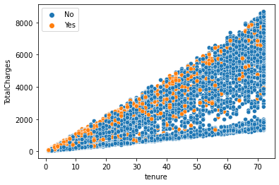

```python
# Create a scatter plot

sns.scatterplot(data = telcom, x =telcom['tenure'], y = telcom['TotalCharges'], hue=telcom.Churn.tolist())
```

### Q2. What does the above plot indicate?

### A2.From the above plot, we can observe information of 3 different variables namely tenure, Total Charges and Churn.

1) We can see that as the tenure increases the total charges is gradually increasing. That is, Higher the tenure higher are the Total Charges. Also, Total Charges and tenure have a positive relationship with each other.

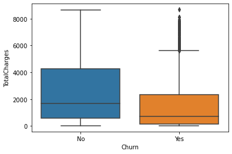

```python
sns.boxplot(data= telcom, x="Churn", y="TotalCharges")
```

### Q3. What does the above plot indicate?

### A3. From the above boxplot, We can notice a number of things. We will look at the customers who churned away from the company first followed by the customers who were loyal:

1) We can understand that 50% of customers that have churned from the company had total charges ranging from approximately 50 to 2100. While there were some customers that churned who had high total charges ( > 6000) as well. The average value of total charges for which the most customers left is approximately 600. The middle 50% of customers as mentioned previously are having 1/4th of the highest total charges possible in the company which means that the higher paying customers are loyal which is a good performance indicator even though there are some exceptions to this phenomenon.

2) When we look at the customers that were loyal we can see that the middle 50% of the customers have total charges ranging from approximately 600 to 4200. The other customers are spread across the entire range of Total Charges. The average value of total charges for which the most customers stayed in the company is approximately 1800.

# Exploratory Data Analysis

# Churn No-Churn Ratio

```python
# labels

lab = telcom["Churn"].value_counts().keys().tolist()

# Values

val = telcom["Churn"].value_counts().values.tolist()

trace = go.Pie(labels = lab ,
               values = val ,
               marker = dict(colors =  [ 'royalblue' ,'lime'],
                             line = dict(color = "white",
                                         width =  1.3)
                            ),
               rotation = 90,
               hoverinfo = "label+value+text",
               hole = .5
              )
layout = go.Layout(dict(title = "Churn vs. Non-Churn",
                        plot_bgcolor  = "rgb(243,243,243)",
                        paper_bgcolor = "rgb(243,243,243)",
                       )
                  )

data = [trace]
fig = go.Figure(data = data,layout = layout)

py.iplot(fig)
```

[interactive chart not shown]

### Q4. Comment on this distribution

### A4. The above distribution in plot suggests that from the overall customers we have had 73.4% will not leave the company whereas 26.6% will leave the company.

```python
data
```

```
[Pie({
     'hole': 0.5,
     'hoverinfo': 'label+value+text',
     'labels': [No, Yes],
     'marker': {'colors': ['royalblue', 'lime'], 'line': {'color': 'white', 'width': 1.3}},
     'rotation': 90,
     'values': [5163, 1869]
 })]
```

```python
telcom['Churn'].value_counts()
```

```
No     5163
Yes    1869
Name: Churn, dtype: int64
```

```python
# Save the cleaned file

telcom.to_csv('clean_df.csv')
```

# Variables distribution in Churn and Non-churn category: Pie Charts for Categorical variables

```python
def plot_pie(column) :

    trace1 = go.Pie(values  = churn[column].value_counts().values.tolist(),
                    labels  = churn[column].value_counts().keys().tolist(),
                    hoverinfo = "label+percent+name",
                    domain  = dict(x = [0,.48]),
                    name    = "Churn Customers",
                    marker  = dict(line = dict(width = 2,
                                               color = "rgb(243,243,243)")
                                  ),
                    hole    = .6
                   )
    trace2 = go.Pie(values  = not_churn[column].value_counts().values.tolist(),
                    labels  = not_churn[column].value_counts().keys().tolist(),
                    hoverinfo = "label+percent+name",
                    marker  = dict(line = dict(width = 2,
                                               color = "rgb(243,243,243)")
                                  ),
                    domain  = dict(x = [.52,1]),
                    hole    = .6,
                    name    = "Non churn customers"
                   )


    layout = go.Layout(dict(title = column + " distribution in customer Churn ",
                            plot_bgcolor  = "rgb(243,243,243)",
                            paper_bgcolor = "rgb(243,243,243)",
                            annotations = [dict(text = "churn customers",
                                                font = dict(size = 13),
                                                showarrow = False,
                                                x = .15, y = .5),
                                           dict(text = "Non churn customers",
                                                font = dict(size = 13),
                                                showarrow = False,
                                                x = .88,y = .5
                                               )
                                          ]
                           )
                      )
    data = [trace1,trace2]
    fig  = go.Figure(data = data,layout = layout)
    py.iplot(fig)
```

```python
# For all categorical columns plot pie

for i in cat_cols :
    plot_pie(i)
```

[interactive chart not shown]

### Q5. Comment on each and every chart. Is there any chart that does not make sense?

### A5. In order to have an objective view of the pie charts, we will look at the categories of churn and non-churn separately in order to get an unbiased analysis and compare the two amongst each other wherever necessary or possible or both.

- Gender Distribution

It looks like gender distribution is more or less even regardless of whether it is in churn category of customers or in the non-churn customers. If we focus on the churn customers we cannot give a comprehensive analysis as to why this churn phenomenon is so even amongst the genders. That is this pie chart is inconclusive to give a definite answer about whether or not the company policies are affecting any one gender more than the other.

- Senior Citizen Distribution

Firstly, In the churn category, we can see that a little more than 1/4th of them are senior citizens which could mean either of 2 things: i) The number of senior citizens in the customer age groups is very low. ii) The company policies seem to be quite effective towards the senior citizens and they are choosing to stay.

Secondly, In the non-churn category, we can see that less than 1/7th of the customers are senior citizens which could be attributed to the same reasons mentioned above.

- Partner Distribution

Firstly, in the churn category, we can see that 35.8% customers that churned away had partners which means that company should focus on targeting these people more effectively in order to capture this market and extract the benefits. This is because if the customers who have partners' experience is positive with the company, their chances of publicity are higher as 2 people can reach more people merely by word-of-mouth publicity as compared to single people. Also, there is a very good chance that even their next generations will use their services as well.

In the non-churn category we can see that the distribution is more even amongst the customers compared to the above category that is both single as well as customers with partners have stayed loyal to the company. These strategies seem to be working and could be used to target the churn customers category in a different manner or in the same manner with a little more care and effort.

- Dependents Distribution

We can see that the loyal customers are the ones with a higher percentage of dependents(34.3%) and the customers that are leaving have a dependents distribution of 17.4% only.

- PhoneService Distribution

We can see that regardless of whether a customer is loyal or leaving more than 90% of the customers in both the categories had a phoneService installed.

- Multiple Lines Distribution

We can see that the customers that are churning away have had almost equal distribution of customers with multiple lines employed and only 1 section of customers in both the categories (less than 10%) had no phone service.

- Internet Service Distribution

We can see a very important phenomenon in these pie charts. The customers who churned away had the highest percentage (69.4%) of customers using Fiber Optic connections, that is were consequently paying the most as compared to other connection modes. But they churned away for various reasons and Telco should find ways to capitalize on this opportunity in order to increase their growth.

- Online Security Distribution

We can see that regardless of whether a customer is loyal or leaving, more than 65% of customers had opted out of having online security. This is concerning and should be worked on by Telco.

- Online Backup Distribution

We can see that regardless of whether a customer is loyal or not, more than 62% of customers had opted out of having onling backup. This is concerning and should be targeted by Telco.

- Device Protection Distribution

This dangerous trend seems to be trickling into other services like Device protection as well where the customers are opting out of having protection. More than 60% of the customers in both the categories have not opted for having device protection.

- Tech Support Distribution

It looks like since the customers have opted out of having security or protection most of them have not opted for having tech support as well.

- Streaming TV Distribution

If we look at the previous 4 services, it looks like customers are in general not very happy to go for their services. Even the Streaming TV service has not been chosen by a majority of the customers in both the categories.

- Streaming Movies Distribution

We can see that most of the customers are not opting to have a streaming movies service as well. Following from the above trend, we can see that the same trend is being followed here.

- Contract Distribution

The company provides 3 different contract options namely Month-to-Month, One Year and Two Years. The Month-to-Month contract option is the most picked option by the customers regardless of the category. In the churn category, 8.88% of the customers have picked one-year option while remaining 2.57% have picked two-year options. Telco should focus on encouraging customers to pick the longer term contracts and focus on keeping them happy with their choices.

- Paperless Billing Distribution

When it comes to billing, customers are choosing the environment friendly option regardless of the category. 74.9% customers in the churn category and 53.6% in the non churn category have picked this option.

- Payment Method Distribution

The customers have 4 options when it comes to payment methods namely Electronic Check, Mailed Check, Bank Transfer and Credit Card. For the churn customers, the preferred method of payment was Electronic Check with a percentage of 57.3%, followed by Mailed Check, Bank Transfer and finally Credit Card.

For the non-churn category, the preference is almost equally divided amongst the 4 payment methods.

- Tenure Group Distribution

The customers have been divided in 5 broad categories based on their time with the company namely Tenure 0-12, Tenure 12-24, Tenure 24-48, Tenure 48-60, Tenure gt_60.

In the Churn category, we can see that majority of the customers (55.5%) have left in the smallest time (0-12). That is customers are extremely unhappy and the company needs to focus on this to improve their financial standing and grow further.

In the Non-churn category, we can see that majority of the loyal customers have been loyal for the longest time which is a positive trait of the company. This shows that they have done well to retain these customers. This needs to be applied to the other groups in an appropriate way to reduce churn and increase the performance of the company.

# Variables distribution in Churn and Non-churn category: Histograms for Numerical variables

```python
# Function  for histogram for customer attrition types

def histogram(column) :
    trace1 = go.Histogram(x  = churn[column],
                          histnorm= "percent",
                          name = "Churn Customers",
                          marker = dict(line = dict(width = .5,
                                                    color = "black"
                                                    )
                                        ),
                         opacity = .9
                         )

    trace2 = go.Histogram(x  = not_churn[column],
                          histnorm = "percent",
                          name = "Non churn customers",
                          marker = dict(line = dict(width = .5,
                                              color = "black"
                                             )
                                 ),
                          opacity = .9
                         )

    data = [trace1,trace2]
    layout = go.Layout(dict(title =column + " distribution in customer Churn ",
                            plot_bgcolor  = "rgb(243,243,243)",
                            paper_bgcolor = "rgb(243,243,243)",
                            xaxis = dict(gridcolor = 'rgb(255, 255, 255)',
                                             title = column,
                                             zerolinewidth=1,
                                             ticklen=5,
                                             gridwidth=2
                                            ),
                            yaxis = dict(gridcolor = 'rgb(255, 255, 255)',
                                             title = "percent",
                                             zerolinewidth=1,
                                             ticklen=5,
                                             gridwidth=2
                                            ),
                           )
                      )
    fig  = go.Figure(data=data,layout=layout)

    py.iplot(fig)
```

```python
# For all categorical columns plot histogram

for i in num_cols :
    histogram(i)
plt.show()
```

[interactive chart not shown]

### Q6. Comment on each and every chart. Is there any chart that does not make sense?

### A6.

- Tenure Distribution in Customer Churn

We can see that the majority of the churn customers have the lowest tenure. As the tenure increases the churn rate(percent) majorly decreases. This trend seems to be almost constant throughout the entire tenure terms.

On the other hand, the non-churn customers have a non-linear relationship where with increasing tenure the percentage of non-churn customers is decreasing initially, then it stays constant for a while and it increases towards the end.

- Monthly Charges Distribution in Customer Churn

We can see that the when the monthly charges are higher for the customers the churn rate is also very high. This is concerning as this means that the higher paying hence higher benefitting customers are leaving.

- Total Charges Distribution in Customer Churn

We can see that as the Total charges increases, both the churn and non-churn customer percentage is decreasing. They have a negative relationship with each other.

# Scatter Plot for Numerical variables

```python
# Function  for scatter plot matrix  for numerical columns in data

def scatter_matrix(df)  :

    df  = df.sort_values(by = "Churn" ,ascending = True)
    classes = df["Churn"].unique().tolist()
    classes

    class_code  = {classes[k] : k for k in range(2)}
    class_code

    color_vals = [class_code[cl] for cl in df["Churn"]]
    color_vals

    pl_colorscale = "Portland"

    pl_colorscale

    text = [df.loc[k,"Churn"] for k in range(len(df))]
    text

    trace = go.Splom(dimensions = [dict(label  = "tenure",
                                       values = df["tenure"]),
                                  dict(label  = 'MonthlyCharges',
                                       values = df['MonthlyCharges']),
                                  dict(label  = 'TotalCharges',
                                       values = df['TotalCharges'])],
                     text = text,
                     marker = dict(color = color_vals,
                                   colorscale = pl_colorscale,
                                   size = 3,
                                   showscale = False,
                                   line = dict(width = .1,
                                               color='rgb(230,230,230)'
                                              )
                                  )
                    )
    axis = dict(showline  = True,
                zeroline  = False,
                gridcolor = "#fff",
                ticklen   = 4
               )

    layout = go.Layout(dict(title  =
                            "Scatter plot matrix for Numerical columns for customer churn",
                            autosize = False,
                            height = 800,
                            width  = 800,
                            dragmode = "select",
                            hovermode = "closest",
                            plot_bgcolor  = 'rgba(240,240,240, 0.95)',
                            xaxis1 = dict(axis),
                            yaxis1 = dict(axis),
                            xaxis2 = dict(axis),
                            yaxis2 = dict(axis),
                            xaxis3 = dict(axis),
                            yaxis3 = dict(axis),
                           )
                      )
    data   = [trace]
    fig = go.Figure(data = data,layout = layout )
    py.iplot(fig)
```

```python
# Scatter plot matrix

scatter_matrix(telcom)
```

[interactive chart not shown]

# Data Pre-Processing

```python
from sklearn.preprocessing import LabelEncoder
from sklearn.preprocessing import StandardScaler


# Customer id col

Id_col     = ['customerID']

# Target columns

target_col = ["Churn"]

# Categorical columns

cat_cols   = telcom.nunique()[telcom.nunique() < 6].keys().tolist()
cat_cols   = [x for x in cat_cols if x not in target_col]

# Numerical columns

num_cols   = [x for x in telcom.columns if x not in cat_cols + target_col + Id_col]

# Binary columns with 2 values

bin_cols   = telcom.nunique()[telcom.nunique() == 2].keys().tolist()

# Columns more than 2 values

multi_cols = [i for i in cat_cols if i not in bin_cols]
```

```python
multi_cols
```

```
['MultipleLines',
 'InternetService',
 'Contract',
 'PaymentMethod',
 'tenure_group']
```

```python
# Label encoding Binary columns

le = LabelEncoder()
for i in bin_cols :
    telcom[i] = le.fit_transform(telcom[i])

# Duplicating columns for multi value columns

telcom = pd.get_dummies(data = telcom,columns = multi_cols)
```

```python
telcom
```

|  | customerID | gender | SeniorCitizen | Partner | Dependents | tenure | PhoneService | OnlineSecurity | OnlineBackup | DeviceProtection | ... | Contract_Two year | PaymentMethod_Bank transfer (automatic) | PaymentMethod_Credit card (automatic) | PaymentMethod_Electronic check | PaymentMethod_Mailed check | tenure_group_Tenure_0-12 | tenure_group_Tenure_12-24 | tenure_group_Tenure_24-48 | tenure_group_Tenure_48-60 | tenure_group_Tenure_gt_60 |
| --- | --- | --- | --- | --- | --- | --- | --- | --- | --- | --- | --- | --- | --- | --- | --- | --- | --- | --- | --- | --- | --- |
| 0 | 7590-VHVEG | 0 | 0 | 1 | 0 | 1 | 0 | 0 | 1 | 0 | ... | 0 | 0 | 0 | 1 | 0 | 1 | 0 | 0 | 0 | 0 |
| 1 | 5575-GNVDE | 1 | 0 | 0 | 0 | 34 | 1 | 1 | 0 | 1 | ... | 0 | 0 | 0 | 0 | 1 | 0 | 0 | 1 | 0 | 0 |
| 2 | 3668-QPYBK | 1 | 0 | 0 | 0 | 2 | 1 | 1 | 1 | 0 | ... | 0 | 0 | 0 | 0 | 1 | 1 | 0 | 0 | 0 | 0 |
| 3 | 7795-CFOCW | 1 | 0 | 0 | 0 | 45 | 0 | 1 | 0 | 1 | ... | 0 | 1 | 0 | 0 | 0 | 0 | 0 | 1 | 0 | 0 |
| 4 | 9237-HQITU | 0 | 0 | 0 | 0 | 2 | 1 | 0 | 0 | 0 | ... | 0 | 0 | 0 | 1 | 0 | 1 | 0 | 0 | 0 | 0 |
| ... | ... | ... | ... | ... | ... | ... | ... | ... | ... | ... | ... | ... | ... | ... | ... | ... | ... | ... | ... | ... | ... |
| 7027 | 6840-RESVB | 1 | 0 | 1 | 1 | 24 | 1 | 1 | 0 | 1 | ... | 0 | 0 | 0 | 0 | 1 | 0 | 1 | 0 | 0 | 0 |
| 7028 | 2234-XADUH | 0 | 0 | 1 | 1 | 72 | 1 | 0 | 1 | 1 | ... | 0 | 0 | 1 | 0 | 0 | 0 | 0 | 0 | 0 | 1 |
| 7029 | 4801-JZAZL | 0 | 0 | 1 | 1 | 11 | 0 | 1 | 0 | 0 | ... | 0 | 0 | 0 | 1 | 0 | 1 | 0 | 0 | 0 | 0 |
| 7030 | 8361-LTMKD | 1 | 1 | 1 | 0 | 4 | 1 | 0 | 0 | 0 | ... | 0 | 0 | 0 | 0 | 1 | 1 | 0 | 0 | 0 | 0 |
| 7031 | 3186-AJIEK | 1 | 0 | 0 | 0 | 66 | 1 | 1 | 0 | 1 | ... | 1 | 1 | 0 | 0 | 0 | 0 | 0 | 0 | 0 | 1 |

7032 rows × 35 columns

```python
# Scaling Numerical columns

std = StandardScaler()
scaled = std.fit_transform(telcom[num_cols])
scaled = pd.DataFrame(scaled,columns=num_cols)
```

```python
scaled
```

|  | tenure | MonthlyCharges | TotalCharges |
| --- | --- | --- | --- |
| 0 | -1.280248 | -1.161694 | -0.994194 |
| 1 | 0.064303 | -0.260878 | -0.173740 |
| 2 | -1.239504 | -0.363923 | -0.959649 |
| 3 | 0.512486 | -0.747850 | -0.195248 |
| 4 | -1.239504 | 0.196178 | -0.940457 |
| ... | ... | ... | ... |
| 7027 | -0.343137 | 0.664868 | -0.129180 |
| 7028 | 1.612573 | 1.276493 | 2.241056 |
| 7029 | -0.872808 | -1.170004 | -0.854514 |
| 7030 | -1.158016 | 0.319168 | -0.872095 |
| 7031 | 1.368109 | 1.357932 | 2.012344 |

7032 rows × 3 columns

# df_telcom_original

```python
telcom = telcom.drop(columns = num_cols,axis = 1)
telcom = telcom.merge(scaled,left_index=True,right_index=True,how = "left")
```

```python
telcom
```

|  | customerID | gender | SeniorCitizen | Partner | Dependents | PhoneService | OnlineSecurity | OnlineBackup | DeviceProtection | TechSupport | ... | PaymentMethod_Electronic check | PaymentMethod_Mailed check | tenure_group_Tenure_0-12 | tenure_group_Tenure_12-24 | tenure_group_Tenure_24-48 | tenure_group_Tenure_48-60 | tenure_group_Tenure_gt_60 | tenure | MonthlyCharges | TotalCharges |
| --- | --- | --- | --- | --- | --- | --- | --- | --- | --- | --- | --- | --- | --- | --- | --- | --- | --- | --- | --- | --- | --- |
| 0 | 7590-VHVEG | 0 | 0 | 1 | 0 | 0 | 0 | 1 | 0 | 0 | ... | 1 | 0 | 1 | 0 | 0 | 0 | 0 | -1.280248 | -1.161694 | -0.994194 |
| 1 | 5575-GNVDE | 1 | 0 | 0 | 0 | 1 | 1 | 0 | 1 | 0 | ... | 0 | 1 | 0 | 0 | 1 | 0 | 0 | 0.064303 | -0.260878 | -0.173740 |
| 2 | 3668-QPYBK | 1 | 0 | 0 | 0 | 1 | 1 | 1 | 0 | 0 | ... | 0 | 1 | 1 | 0 | 0 | 0 | 0 | -1.239504 | -0.363923 | -0.959649 |
| 3 | 7795-CFOCW | 1 | 0 | 0 | 0 | 0 | 1 | 0 | 1 | 1 | ... | 0 | 0 | 0 | 0 | 1 | 0 | 0 | 0.512486 | -0.747850 | -0.195248 |
| 4 | 9237-HQITU | 0 | 0 | 0 | 0 | 1 | 0 | 0 | 0 | 0 | ... | 1 | 0 | 1 | 0 | 0 | 0 | 0 | -1.239504 | 0.196178 | -0.940457 |
| ... | ... | ... | ... | ... | ... | ... | ... | ... | ... | ... | ... | ... | ... | ... | ... | ... | ... | ... | ... | ... | ... |
| 7027 | 6840-RESVB | 1 | 0 | 1 | 1 | 1 | 1 | 0 | 1 | 1 | ... | 0 | 1 | 0 | 1 | 0 | 0 | 0 | -0.343137 | 0.664868 | -0.129180 |
| 7028 | 2234-XADUH | 0 | 0 | 1 | 1 | 1 | 0 | 1 | 1 | 0 | ... | 0 | 0 | 0 | 0 | 0 | 0 | 1 | 1.612573 | 1.276493 | 2.241056 |
| 7029 | 4801-JZAZL | 0 | 0 | 1 | 1 | 0 | 1 | 0 | 0 | 0 | ... | 1 | 0 | 1 | 0 | 0 | 0 | 0 | -0.872808 | -1.170004 | -0.854514 |
| 7030 | 8361-LTMKD | 1 | 1 | 1 | 0 | 1 | 0 | 0 | 0 | 0 | ... | 0 | 1 | 1 | 0 | 0 | 0 | 0 | -1.158016 | 0.319168 | -0.872095 |
| 7031 | 3186-AJIEK | 1 | 0 | 0 | 0 | 1 | 1 | 0 | 1 | 1 | ... | 0 | 0 | 0 | 0 | 0 | 0 | 1 | 1.368109 | 1.357932 | 2.012344 |

7032 rows × 35 columns

```python
summary = telcom.describe().transpose()
summary
```

|  | count | mean | std | min | 25% | 50% | 75% | max |
| --- | --- | --- | --- | --- | --- | --- | --- | --- |
| gender | 7032.0 | 5.046928e-01 | 0.500014 | 0.000000 | 0.000000 | 1.000000 | 1.000000 | 1.000000 |
| SeniorCitizen | 7032.0 | 1.624005e-01 | 0.368844 | 0.000000 | 0.000000 | 0.000000 | 0.000000 | 1.000000 |
| Partner | 7032.0 | 4.825085e-01 | 0.499729 | 0.000000 | 0.000000 | 0.000000 | 1.000000 | 1.000000 |
| Dependents | 7032.0 | 2.984926e-01 | 0.457629 | 0.000000 | 0.000000 | 0.000000 | 1.000000 | 1.000000 |
| PhoneService | 7032.0 | 9.032992e-01 | 0.295571 | 0.000000 | 1.000000 | 1.000000 | 1.000000 | 1.000000 |
| OnlineSecurity | 7032.0 | 2.865472e-01 | 0.452180 | 0.000000 | 0.000000 | 0.000000 | 1.000000 | 1.000000 |
| OnlineBackup | 7032.0 | 3.448521e-01 | 0.475354 | 0.000000 | 0.000000 | 0.000000 | 1.000000 | 1.000000 |
| DeviceProtection | 7032.0 | 3.438567e-01 | 0.475028 | 0.000000 | 0.000000 | 0.000000 | 1.000000 | 1.000000 |
| TechSupport | 7032.0 | 2.901024e-01 | 0.453842 | 0.000000 | 0.000000 | 0.000000 | 1.000000 | 1.000000 |
| StreamingTV | 7032.0 | 3.843857e-01 | 0.486484 | 0.000000 | 0.000000 | 0.000000 | 1.000000 | 1.000000 |
| StreamingMovies | 7032.0 | 3.883675e-01 | 0.487414 | 0.000000 | 0.000000 | 0.000000 | 1.000000 | 1.000000 |
| PaperlessBilling | 7032.0 | 5.927190e-01 | 0.491363 | 0.000000 | 0.000000 | 1.000000 | 1.000000 | 1.000000 |
| Churn | 7032.0 | 2.657850e-01 | 0.441782 | 0.000000 | 0.000000 | 0.000000 | 1.000000 | 1.000000 |
| MultipleLines_No | 7032.0 | 4.813709e-01 | 0.499688 | 0.000000 | 0.000000 | 0.000000 | 1.000000 | 1.000000 |
| MultipleLines_No phone service | 7032.0 | 9.670080e-02 | 0.295571 | 0.000000 | 0.000000 | 0.000000 | 0.000000 | 1.000000 |
| MultipleLines_Yes | 7032.0 | 4.219283e-01 | 0.493902 | 0.000000 | 0.000000 | 0.000000 | 1.000000 | 1.000000 |
| InternetService_DSL | 7032.0 | 3.435722e-01 | 0.474934 | 0.000000 | 0.000000 | 0.000000 | 1.000000 | 1.000000 |
| InternetService_Fiber optic | 7032.0 | 4.402730e-01 | 0.496455 | 0.000000 | 0.000000 | 0.000000 | 1.000000 | 1.000000 |
| InternetService_No | 7032.0 | 2.161547e-01 | 0.411650 | 0.000000 | 0.000000 | 0.000000 | 0.000000 | 1.000000 |
| Contract_Month-to-month | 7032.0 | 5.510523e-01 | 0.497422 | 0.000000 | 0.000000 | 1.000000 | 1.000000 | 1.000000 |
| Contract_One year | 7032.0 | 2.093288e-01 | 0.406858 | 0.000000 | 0.000000 | 0.000000 | 0.000000 | 1.000000 |
| Contract_Two year | 7032.0 | 2.396189e-01 | 0.426881 | 0.000000 | 0.000000 | 0.000000 | 0.000000 | 1.000000 |
| PaymentMethod_Bank transfer (automatic) | 7032.0 | 2.192833e-01 | 0.413790 | 0.000000 | 0.000000 | 0.000000 | 0.000000 | 1.000000 |
| PaymentMethod_Credit card (automatic) | 7032.0 | 2.162969e-01 | 0.411748 | 0.000000 | 0.000000 | 0.000000 | 0.000000 | 1.000000 |
| PaymentMethod_Electronic check | 7032.0 | 3.363197e-01 | 0.472483 | 0.000000 | 0.000000 | 0.000000 | 1.000000 | 1.000000 |
| PaymentMethod_Mailed check | 7032.0 | 2.281001e-01 | 0.419637 | 0.000000 | 0.000000 | 0.000000 | 0.000000 | 1.000000 |
| tenure_group_Tenure_0-12 | 7032.0 | 3.093003e-01 | 0.462238 | 0.000000 | 0.000000 | 0.000000 | 1.000000 | 1.000000 |
| tenure_group_Tenure_12-24 | 7032.0 | 1.456200e-01 | 0.352750 | 0.000000 | 0.000000 | 0.000000 | 0.000000 | 1.000000 |
| tenure_group_Tenure_24-48 | 7032.0 | 2.266780e-01 | 0.418712 | 0.000000 | 0.000000 | 0.000000 | 0.000000 | 1.000000 |
| tenure_group_Tenure_48-60 | 7032.0 | 1.183163e-01 | 0.323005 | 0.000000 | 0.000000 | 0.000000 | 0.000000 | 1.000000 |
| tenure_group_Tenure_gt_60 | 7032.0 | 2.000853e-01 | 0.400092 | 0.000000 | 0.000000 | 0.000000 | 0.000000 | 1.000000 |
| tenure | 7032.0 | -1.214741e-16 | 1.000071 | -1.280248 | -0.954296 | -0.139417 | 0.919926 | 1.612573 |
| MonthlyCharges | 7032.0 | 9.652878e-17 | 1.000071 | -1.547283 | -0.970977 | 0.184544 | 0.833148 | 1.793381 |
| TotalCharges | 7032.0 | -1.172113e-16 | 1.000071 | -0.999069 | -0.830249 | -0.390815 | 0.666827 | 2.824261 |

# Variable Summary

```python
# To make it look nice we can do some additional stuff if needed

summary = (telcom[[i for i in telcom.columns if i not in Id_col]].
           describe().transpose().reset_index())

summary = summary.rename(columns = {"index" : "feature"})
summary = np.around(summary,3)

val_lst = [summary['feature'], summary['count'],
           summary['mean'],summary['std'],
           summary['min'], summary['25%'],
           summary['50%'], summary['75%'], summary['max']]

trace  = go.Table(header = dict(values = summary.columns.tolist(),
                                line = dict(color = ['#506784']),
                                fill = dict(color = ['#119DFF']),
                               ),
                  cells  = dict(values = val_lst,
                                line = dict(color = ['#506784']),
                                fill = dict(color = ["lightgrey",'#F5F8FF'])
                               ),
                  columnwidth = [200,60,100,100,60,60,80,80,80])
layout = go.Layout(dict(title = "Variable Summary"))
figure = go.Figure(data=[trace],layout=layout)
py.iplot(figure)
```

[interactive chart not shown]

```python
# Correlation

correlation = telcom.corr()

# Tick labels

matrix_cols = correlation.columns.tolist()
```

```python
# Convert to array
corr_array  = np.array(correlation)
```

```python
correlation
```

|  | gender | SeniorCitizen | Partner | Dependents | PhoneService | OnlineSecurity | OnlineBackup | DeviceProtection | TechSupport | StreamingTV | ... | PaymentMethod_Electronic check | PaymentMethod_Mailed check | tenure_group_Tenure_0-12 | tenure_group_Tenure_12-24 | tenure_group_Tenure_24-48 | tenure_group_Tenure_48-60 | tenure_group_Tenure_gt_60 | tenure | MonthlyCharges | TotalCharges |
| --- | --- | --- | --- | --- | --- | --- | --- | --- | --- | --- | --- | --- | --- | --- | --- | --- | --- | --- | --- | --- | --- |
| gender | 1.000000 | -0.001819 | -0.001379 | 0.010349 | -0.007515 | -0.016328 | -0.013093 | -0.000807 | -0.008507 | -0.007124 | ... | 0.000844 | 0.013199 | -0.001050 | -0.000649 | -0.010516 | -0.004319 | 0.016279 | 0.005285 | -0.013779 | 0.000048 |
| SeniorCitizen | -0.001819 | 1.000000 | 0.016957 | -0.210550 | 0.008392 | -0.038576 | 0.066663 | 0.059514 | -0.060577 | 0.105445 | ... | 0.171322 | -0.152987 | -0.027713 | 0.001860 | 0.020383 | 0.014186 | -0.002407 | 0.015683 | 0.219874 | 0.102411 |
| Partner | -0.001379 | 0.016957 | 1.000000 | 0.452269 | 0.018397 | 0.143346 | 0.141849 | 0.153556 | 0.120206 | 0.124483 | ... | -0.083207 | -0.096948 | -0.305061 | -0.048481 | 0.028468 | 0.105341 | 0.280353 | 0.381912 | 0.097825 | 0.319072 |
| Dependents | 0.010349 | -0.210550 | 0.452269 | 1.000000 | -0.001078 | 0.080786 | 0.023639 | 0.013900 | 0.063053 | -0.016499 | ... | -0.149274 | 0.056448 | -0.145379 | -0.001459 | 0.024645 | 0.031419 | 0.118090 | 0.163386 | -0.112343 | 0.064653 |
| PhoneService | -0.007515 | 0.008392 | 0.018397 | -0.001078 | 1.000000 | -0.091676 | -0.052133 | -0.070076 | -0.095138 | -0.021383 | ... | 0.002747 | -0.004463 | -0.006950 | 0.012307 | -0.014778 | -0.009750 | 0.020516 | 0.007877 | 0.248033 | 0.113008 |
| OnlineSecurity | -0.016328 | -0.038576 | 0.143346 | 0.080786 | -0.091676 | 1.000000 | 0.283285 | 0.274875 | 0.354458 | 0.175514 | ... | -0.112295 | -0.079918 | -0.242409 | -0.055662 | 0.007695 | 0.071663 | 0.263228 | 0.328297 | 0.296447 | 0.412619 |
| OnlineBackup | -0.013093 | 0.066663 | 0.141849 | 0.023639 | -0.052133 | 0.283285 | 1.000000 | 0.303058 | 0.293705 | 0.281601 | ... | -0.000364 | -0.174075 | -0.267366 | -0.084081 | 0.023085 | 0.099192 | 0.278788 | 0.361138 | 0.441529 | 0.510100 |
| DeviceProtection | -0.000807 | 0.059514 | 0.153556 | 0.013900 | -0.070076 | 0.274875 | 0.303058 | 1.000000 | 0.332850 | 0.389924 | ... | -0.003308 | -0.187325 | -0.273920 | -0.077332 | 0.044972 | 0.076854 | 0.275537 | 0.361520 | 0.482607 | 0.522881 |
| TechSupport | -0.008507 | -0.060577 | 0.120206 | 0.063053 | -0.095138 | 0.354458 | 0.293705 | 0.332850 | 1.000000 | 0.277549 | ... | -0.114807 | -0.084631 | -0.238628 | -0.072019 | 0.022137 | 0.062710 | 0.265396 | 0.325288 | 0.338301 | 0.432868 |
| StreamingTV | -0.007124 | 0.105445 | 0.124483 | -0.016499 | -0.021383 | 0.175514 | 0.281601 | 0.389924 | 0.277549 | 1.000000 | ... | 0.144747 | -0.247712 | -0.220761 | -0.050234 | 0.028829 | 0.087969 | 0.198150 | 0.280264 | 0.629668 | 0.515709 |
| StreamingMovies | -0.010105 | 0.119842 | 0.118108 | -0.038375 | -0.033477 | 0.187426 | 0.274523 | 0.402309 | 0.280155 | 0.533380 | ... | 0.137420 | -0.250290 | -0.221388 | -0.054338 | 0.025048 | 0.086616 | 0.207544 | 0.285402 | 0.627235 | 0.519867 |
| PaperlessBilling | -0.011902 | 0.156258 | -0.013957 | -0.110131 | 0.016696 | -0.004051 | 0.127056 | 0.104079 | 0.037536 | 0.224241 | ... | 0.208427 | -0.203981 | -0.003860 | 0.003328 | -0.005388 | 0.010626 | -0.001415 | 0.004823 | 0.351930 | 0.157830 |
| Churn | -0.008545 | 0.150541 | -0.149982 | -0.163128 | 0.011691 | -0.171270 | -0.082307 | -0.066193 | -0.164716 | 0.063254 | ... | 0.301455 | -0.090773 | 0.319628 | 0.019929 | -0.075859 | -0.100800 | -0.226078 | -0.354049 | 0.192858 | -0.199484 |
| MultipleLines_No | 0.004335 | -0.136377 | -0.130028 | 0.023388 | 0.315218 | -0.151678 | -0.230724 | -0.240847 | -0.155534 | -0.267466 | ... | -0.080990 | 0.222395 | 0.256171 | 0.051703 | -0.032157 | -0.080630 | -0.242798 | -0.323891 | -0.338514 | -0.396765 |
| MultipleLines_No phone service | 0.007515 | -0.008392 | -0.018397 | 0.001078 | -1.000000 | 0.091676 | 0.052133 | 0.070076 | 0.095138 | 0.021383 | ... | -0.002747 | 0.004463 | 0.006950 | -0.012307 | 0.014778 | 0.009750 | -0.020516 | -0.007877 | -0.248033 | -0.113008 |
| MultipleLines_Yes | -0.008883 | 0.142996 | 0.142561 | -0.024307 | 0.279530 | 0.098592 | 0.202228 | 0.201733 | 0.100421 | 0.257804 | ... | 0.083583 | -0.227672 | -0.263331 | -0.044944 | 0.023690 | 0.075740 | 0.257920 | 0.332399 | 0.490912 | 0.469042 |
| InternetService_DSL | 0.007584 | -0.108276 | -0.001043 | 0.051593 | -0.452255 | 0.320343 | 0.156765 | 0.145150 | 0.312183 | 0.014973 | ... | -0.104293 | 0.042754 | -0.001470 | -0.013429 | -0.000468 | -0.000790 | 0.014666 | 0.013786 | -0.161368 | -0.052190 |
| InternetService_Fiber optic | -0.011189 | 0.254923 | 0.001235 | -0.164101 | 0.290183 | -0.030506 | 0.165940 | 0.176356 | -0.020299 | 0.329744 | ... | 0.335763 | -0.305984 | -0.021441 | -0.001494 | 0.005614 | 0.017466 | 0.006112 | 0.017930 | 0.787195 | 0.360769 |
| InternetService_No | 0.004745 | -0.182519 | -0.000286 | 0.138383 | 0.171817 | -0.332799 | -0.380990 | -0.380151 | -0.335695 | -0.414951 | ... | -0.284608 | 0.319694 | 0.027554 | 0.017295 | -0.006230 | -0.020153 | -0.024292 | -0.037529 | -0.763191 | -0.374878 |
| Contract_Month-to-month | -0.003251 | 0.137752 | -0.280202 | -0.229715 | -0.001243 | -0.246844 | -0.164393 | -0.225988 | -0.285491 | -0.112550 | ... | 0.330879 | 0.006209 | 0.492052 | 0.140004 | -0.052156 | -0.198709 | -0.476912 | -0.649346 | 0.058933 | -0.446776 |
| Contract_One year | 0.007755 | -0.046491 | 0.083067 | 0.069222 | -0.003142 | 0.100658 | 0.084113 | 0.102911 | 0.096258 | 0.061930 | ... | -0.109546 | 0.000197 | -0.251299 | -0.017196 | 0.153893 | 0.158917 | 0.016142 | 0.202338 | 0.004810 | 0.170569 |
| Contract_Two year | -0.003603 | -0.116205 | 0.247334 | 0.201699 | 0.004442 | 0.191698 | 0.111391 | 0.165248 | 0.240924 | 0.072124 | ... | -0.281147 | -0.007423 | -0.333850 | -0.146749 | -0.085900 | 0.080082 | 0.540336 | 0.563801 | -0.073256 | 0.358036 |
| PaymentMethod_Bank transfer (automatic) | -0.015973 | -0.016235 | 0.111406 | 0.052369 | 0.008271 | 0.094366 | 0.086942 | 0.083047 | 0.100472 | 0.046121 | ... | -0.377270 | -0.288097 | -0.185855 | -0.046329 | 0.021723 | 0.060183 | 0.184249 | 0.243822 | 0.042410 | 0.186119 |
| PaymentMethod_Credit card (automatic) | 0.001632 | -0.024359 | 0.082327 | 0.061134 | -0.006916 | 0.115473 | 0.090455 | 0.111252 | 0.117024 | 0.040010 | ... | -0.373978 | -0.285583 | -0.184165 | -0.039647 | 0.028233 | 0.048167 | 0.179294 | 0.232800 | 0.030055 | 0.182663 |
| PaymentMethod_Electronic check | 0.000844 | 0.171322 | -0.083207 | -0.149274 | 0.002747 | -0.112295 | -0.000364 | -0.003308 | -0.114807 | 0.144747 | ... | 1.000000 | -0.386971 | 0.160530 | 0.030387 | -0.011570 | -0.030584 | -0.175456 | -0.210197 | 0.271117 | -0.060436 |
| PaymentMethod_Mailed check | 0.013199 | -0.152987 | -0.096948 | 0.056448 | -0.004463 | -0.079918 | -0.174075 | -0.187325 | -0.084631 | -0.247712 | ... | -0.386971 | 1.000000 | 0.183222 | 0.050371 | -0.036095 | -0.072170 | -0.160053 | -0.232181 | -0.376568 | -0.294708 |
| tenure_group_Tenure_0-12 | -0.001050 | -0.027713 | -0.305061 | -0.145379 | -0.006950 | -0.242409 | -0.267366 | -0.273920 | -0.238628 | -0.220761 | ... | 0.160530 | 0.183222 | 1.000000 | -0.276268 | -0.362302 | -0.245138 | -0.334681 | -0.754330 | -0.191881 | -0.592443 |
| tenure_group_Tenure_12-24 | -0.000649 | 0.001860 | -0.048481 | -0.001459 | 0.012307 | -0.055662 | -0.084081 | -0.077332 | -0.072019 | -0.050234 | ... | 0.030387 | 0.050371 | -0.276268 | 1.000000 | -0.223516 | -0.151234 | -0.206477 | -0.236673 | -0.047220 | -0.210745 |
| tenure_group_Tenure_24-48 | -0.010516 | 0.020383 | 0.028468 | 0.024645 | -0.014778 | 0.007695 | 0.023085 | 0.044972 | 0.022137 | 0.028829 | ... | -0.011570 | -0.036095 | -0.362302 | -0.223516 | 1.000000 | -0.198331 | -0.270776 | 0.083153 | 0.020378 | 0.025594 |
| tenure_group_Tenure_48-60 | -0.004319 | 0.014186 | 0.105341 | 0.031419 | -0.009750 | 0.071663 | 0.099192 | 0.076854 | 0.062710 | 0.087969 | ... | -0.030584 | -0.072170 | -0.245138 | -0.151234 | -0.198331 | 1.000000 | -0.183211 | 0.329367 | 0.070048 | 0.252905 |
| tenure_group_Tenure_gt_60 | 0.016279 | -0.002407 | 0.280353 | 0.118090 | 0.020516 | 0.263228 | 0.278788 | 0.275537 | 0.265396 | 0.198150 | ... | -0.175456 | -0.160053 | -0.334681 | -0.206477 | -0.270776 | -0.183211 | 1.000000 | 0.727237 | 0.185440 | 0.639312 |
| tenure | 0.005285 | 0.015683 | 0.381912 | 0.163386 | 0.007877 | 0.328297 | 0.361138 | 0.361520 | 0.325288 | 0.280264 | ... | -0.210197 | -0.232181 | -0.754330 | -0.236673 | 0.083153 | 0.329367 | 0.727237 | 1.000000 | 0.246862 | 0.825880 |
| MonthlyCharges | -0.013779 | 0.219874 | 0.097825 | -0.112343 | 0.248033 | 0.296447 | 0.441529 | 0.482607 | 0.338301 | 0.629668 | ... | 0.271117 | -0.376568 | -0.191881 | -0.047220 | 0.020378 | 0.070048 | 0.185440 | 0.246862 | 1.000000 | 0.651065 |
| TotalCharges | 0.000048 | 0.102411 | 0.319072 | 0.064653 | 0.113008 | 0.412619 | 0.510100 | 0.522881 | 0.432868 | 0.515709 | ... | -0.060436 | -0.294708 | -0.592443 | -0.210745 | 0.025594 | 0.252905 | 0.639312 | 0.825880 | 0.651065 | 1.000000 |

34 rows × 34 columns

```python
# Plotting

trace = go.Heatmap(z = corr_array,
                   x = matrix_cols,
                   y = matrix_cols,
                   colorscale = "Viridis",
                   colorbar   = dict(title = "Pearson Correlation coefficient",
                                     titleside = "right"
                                    ) ,
                  )

layout = go.Layout(dict(title = "Correlation Matrix for variables",
                        autosize = False,
                        height  = 720,
                        width   = 800,
                        margin  = dict(r = 0 ,l = 210,
                                       t = 25,b = 210,
                                      ),
                        yaxis   = dict(tickfont = dict(size = 9)),
                        xaxis   = dict(tickfont = dict(size = 9))
                       )
                  )

data = [trace]
fig = go.Figure(data=data,layout=layout)
py.iplot(fig)
```

[interactive chart not shown]

### Q7. What do you observe?

### A7. In the given correlation matrix we can see that Total Charges and Tenure have a very strong positive relationship with each other with a z-value of 0.826. While Monthly Charges and No_Internet Service have a very strong negative relationship with each other with a z-value of -0.763.

### Also, Streaming Movies and Streaming TV both have a strong positive relationship with Monthly Charges with z-values of 0.627 and 0.629 respectively as one would expect. That is, if Streaming TV and Streaming Movies services have been employed the monthly charges will be higher.

# Churn Prediction Analysis Part 2

```python
# Import all the libraries

import numpy as np # linear algebra
import pandas as pd # data processing, CSV file I/O (e.g. pd.read_csv)
import matplotlib.pyplot as plt # visualization
from PIL import  Image
%matplotlib inline
import seaborn as sns # visualization
import itertools
import warnings
warnings.filterwarnings("ignore")
import plotly.graph_objs as go # visualization
import plotly.offline as py # visualization
```

```python
# Load the cleaned file

telcom = pd.read_csv("clean_df.csv")
pd.set_option("display.max_columns", None)
```

```python
telcom.head()
```

|  | Unnamed: 0 | customerID | gender | SeniorCitizen | Partner | Dependents | tenure | PhoneService | MultipleLines | InternetService | OnlineSecurity | OnlineBackup | DeviceProtection | TechSupport | StreamingTV | StreamingMovies | Contract | PaperlessBilling | PaymentMethod | MonthlyCharges | TotalCharges | Churn | tenure_group |
| --- | --- | --- | --- | --- | --- | --- | --- | --- | --- | --- | --- | --- | --- | --- | --- | --- | --- | --- | --- | --- | --- | --- | --- |
| 0 | 0 | 7590-VHVEG | Female | No | Yes | No | 1 | No | No phone service | DSL | No | Yes | No | No | No | No | Month-to-month | Yes | Electronic check | 29.85 | 29.85 | No | Tenure_0-12 |
| 1 | 1 | 5575-GNVDE | Male | No | No | No | 34 | Yes | No | DSL | Yes | No | Yes | No | No | No | One year | No | Mailed check | 56.95 | 1889.50 | No | Tenure_24-48 |
| 2 | 2 | 3668-QPYBK | Male | No | No | No | 2 | Yes | No | DSL | Yes | Yes | No | No | No | No | Month-to-month | Yes | Mailed check | 53.85 | 108.15 | Yes | Tenure_0-12 |
| 3 | 3 | 7795-CFOCW | Male | No | No | No | 45 | No | No phone service | DSL | Yes | No | Yes | Yes | No | No | One year | No | Bank transfer (automatic) | 42.30 | 1840.75 | No | Tenure_24-48 |
| 4 | 4 | 9237-HQITU | Female | No | No | No | 2 | Yes | No | Fiber optic | No | No | No | No | No | No | Month-to-month | Yes | Electronic check | 70.70 | 151.65 | Yes | Tenure_0-12 |

```python
telcom = telcom.drop('Unnamed: 0', axis = 1)
```

```python
telcom.head()
```

|  | customerID | gender | SeniorCitizen | Partner | Dependents | tenure | PhoneService | MultipleLines | InternetService | OnlineSecurity | OnlineBackup | DeviceProtection | TechSupport | StreamingTV | StreamingMovies | Contract | PaperlessBilling | PaymentMethod | MonthlyCharges | TotalCharges | Churn | tenure_group |
| --- | --- | --- | --- | --- | --- | --- | --- | --- | --- | --- | --- | --- | --- | --- | --- | --- | --- | --- | --- | --- | --- | --- |
| 0 | 7590-VHVEG | Female | No | Yes | No | 1 | No | No phone service | DSL | No | Yes | No | No | No | No | Month-to-month | Yes | Electronic check | 29.85 | 29.85 | No | Tenure_0-12 |
| 1 | 5575-GNVDE | Male | No | No | No | 34 | Yes | No | DSL | Yes | No | Yes | No | No | No | One year | No | Mailed check | 56.95 | 1889.50 | No | Tenure_24-48 |
| 2 | 3668-QPYBK | Male | No | No | No | 2 | Yes | No | DSL | Yes | Yes | No | No | No | No | Month-to-month | Yes | Mailed check | 53.85 | 108.15 | Yes | Tenure_0-12 |
| 3 | 7795-CFOCW | Male | No | No | No | 45 | No | No phone service | DSL | Yes | No | Yes | Yes | No | No | One year | No | Bank transfer (automatic) | 42.30 | 1840.75 | No | Tenure_24-48 |
| 4 | 9237-HQITU | Female | No | No | No | 2 | Yes | No | Fiber optic | No | No | No | No | No | No | Month-to-month | Yes | Electronic check | 70.70 | 151.65 | Yes | Tenure_0-12 |

```python
from sklearn.preprocessing import LabelEncoder
from sklearn.preprocessing import StandardScaler


# Customer id col

Id_col     = ['customerID']

# Target columns

target_col = ["Churn"]

# Categorical columns

cat_cols   = telcom.nunique()[telcom.nunique() < 6].keys().tolist()
cat_cols   = [x for x in cat_cols if x not in target_col]

# Numerical columns

num_cols   = [x for x in telcom.columns if x not in cat_cols + target_col + Id_col]

# Binary columns with 2 values

bin_cols   = telcom.nunique()[telcom.nunique() == 2].keys().tolist()

# Columns more than 2 values

multi_cols = [i for i in cat_cols if i not in bin_cols]
```

```python
multi_cols
```

```
['MultipleLines',
 'InternetService',
 'Contract',
 'PaymentMethod',
 'tenure_group']
```

```python
# Label encoding Binary columns

le = LabelEncoder()
for i in bin_cols :
    telcom[i] = le.fit_transform(telcom[i])

# Duplicating columns for multi value columns

telcom = pd.get_dummies(data = telcom,columns = multi_cols)
```

```python
telcom
```

|  | customerID | gender | SeniorCitizen | Partner | Dependents | tenure | PhoneService | OnlineSecurity | OnlineBackup | DeviceProtection | TechSupport | StreamingTV | StreamingMovies | PaperlessBilling | MonthlyCharges | TotalCharges | Churn | MultipleLines_No | MultipleLines_No phone service | MultipleLines_Yes | InternetService_DSL | InternetService_Fiber optic | InternetService_No | Contract_Month-to-month | Contract_One year | Contract_Two year | PaymentMethod_Bank transfer (automatic) | PaymentMethod_Credit card (automatic) | PaymentMethod_Electronic check | … |
| --- | --- | --- | --- | --- | --- | --- | --- | --- | --- | --- | --- | --- | --- | --- | --- | --- | --- | --- | --- | --- | --- | --- | --- | --- | --- | --- | --- | --- | --- | --- |
| 0 | 7590-VHVEG | 0 | 0 | 1 | 0 | 1 | 0 | 0 | 1 | 0 | 0 | 0 | 0 | 1 | 29.85 | 29.85 | 0 | 0 | 1 | 0 | 1 | 0 | 0 | 1 | 0 | 0 | 0 | 0 | 1 | … |
| 1 | 5575-GNVDE | 1 | 0 | 0 | 0 | 34 | 1 | 1 | 0 | 1 | 0 | 0 | 0 | 0 | 56.95 | 1889.50 | 0 | 1 | 0 | 0 | 1 | 0 | 0 | 0 | 1 | 0 | 0 | 0 | 0 | … |
| 2 | 3668-QPYBK | 1 | 0 | 0 | 0 | 2 | 1 | 1 | 1 | 0 | 0 | 0 | 0 | 1 | 53.85 | 108.15 | 1 | 1 | 0 | 0 | 1 | 0 | 0 | 1 | 0 | 0 | 0 | 0 | 0 | … |
| 3 | 7795-CFOCW | 1 | 0 | 0 | 0 | 45 | 0 | 1 | 0 | 1 | 1 | 0 | 0 | 0 | 42.30 | 1840.75 | 0 | 0 | 1 | 0 | 1 | 0 | 0 | 0 | 1 | 0 | 1 | 0 | 0 | … |
| 4 | 9237-HQITU | 0 | 0 | 0 | 0 | 2 | 1 | 0 | 0 | 0 | 0 | 0 | 0 | 1 | 70.70 | 151.65 | 1 | 1 | 0 | 0 | 0 | 1 | 0 | 1 | 0 | 0 | 0 | 0 | 1 | … |
| ... | ... | ... | ... | ... | ... | ... | ... | ... | ... | ... | ... | ... | ... | ... | ... | ... | ... | ... | ... | ... | ... | ... | ... | ... | ... | ... | ... | ... | ... | … |
| 7027 | 6840-RESVB | 1 | 0 | 1 | 1 | 24 | 1 | 1 | 0 | 1 | 1 | 1 | 1 | 1 | 84.80 | 1990.50 | 0 | 0 | 0 | 1 | 1 | 0 | 0 | 0 | 1 | 0 | 0 | 0 | 0 | … |
| 7028 | 2234-XADUH | 0 | 0 | 1 | 1 | 72 | 1 | 0 | 1 | 1 | 0 | 1 | 1 | 1 | 103.20 | 7362.90 | 0 | 0 | 0 | 1 | 0 | 1 | 0 | 0 | 1 | 0 | 0 | 1 | 0 | … |
| 7029 | 4801-JZAZL | 0 | 0 | 1 | 1 | 11 | 0 | 1 | 0 | 0 | 0 | 0 | 0 | 1 | 29.60 | 346.45 | 0 | 0 | 1 | 0 | 1 | 0 | 0 | 1 | 0 | 0 | 0 | 0 | 1 | … |
| 7030 | 8361-LTMKD | 1 | 1 | 1 | 0 | 4 | 1 | 0 | 0 | 0 | 0 | 0 | 0 | 1 | 74.40 | 306.60 | 1 | 0 | 0 | 1 | 0 | 1 | 0 | 1 | 0 | 0 | 0 | 0 | 0 | … |
| 7031 | 3186-AJIEK | 1 | 0 | 0 | 0 | 66 | 1 | 1 | 0 | 1 | 1 | 1 | 1 | 1 | 105.65 | 6844.50 | 0 | 1 | 0 | 0 | 0 | 1 | 0 | 0 | 0 | 1 | 1 | 0 | 0 | … |

7032 rows × 35 columns

```python
# Scaling Numerical columns

std = StandardScaler()
scaled = std.fit_transform(telcom[num_cols])
scaled = pd.DataFrame(scaled,columns=num_cols)
```

```python
scaled
```

|  | tenure | MonthlyCharges | TotalCharges |
| --- | --- | --- | --- |
| 0 | -1.280248 | -1.161694 | -0.994194 |
| 1 | 0.064303 | -0.260878 | -0.173740 |
| 2 | -1.239504 | -0.363923 | -0.959649 |
| 3 | 0.512486 | -0.747850 | -0.195248 |
| 4 | -1.239504 | 0.196178 | -0.940457 |
| ... | ... | ... | ... |
| 7027 | -0.343137 | 0.664868 | -0.129180 |
| 7028 | 1.612573 | 1.276493 | 2.241056 |
| 7029 | -0.872808 | -1.170004 | -0.854514 |
| 7030 | -1.158016 | 0.319168 | -0.872095 |
| 7031 | 1.368109 | 1.357932 | 2.012344 |

7032 rows × 3 columns

```python
telcom = telcom.drop(columns = num_cols,axis = 1)
telcom = telcom.merge(scaled,left_index=True,right_index=True,how = "left")
```

### Q1. What is the purpose of the above code?

### A1. The purpose that the above code serves is that it removes the numerical columns and left joins the scaled dataframe with cleaned telcom dataframe.

```python
telcom.head()
```

|  | customerID | gender | SeniorCitizen | Partner | Dependents | PhoneService | OnlineSecurity | OnlineBackup | DeviceProtection | TechSupport | StreamingTV | StreamingMovies | PaperlessBilling | Churn | MultipleLines_No | MultipleLines_No phone service | MultipleLines_Yes | InternetService_DSL | InternetService_Fiber optic | InternetService_No | Contract_Month-to-month | Contract_One year | Contract_Two year | PaymentMethod_Bank transfer (automatic) | PaymentMethod_Credit card (automatic) | PaymentMethod_Electronic check | PaymentMethod_Mailed check | tenure_group_Tenure_0-12 | tenure_group_Tenure_12-24 | … |
| --- | --- | --- | --- | --- | --- | --- | --- | --- | --- | --- | --- | --- | --- | --- | --- | --- | --- | --- | --- | --- | --- | --- | --- | --- | --- | --- | --- | --- | --- | --- |
| 0 | 7590-VHVEG | 0 | 0 | 1 | 0 | 0 | 0 | 1 | 0 | 0 | 0 | 0 | 1 | 0 | 0 | 1 | 0 | 1 | 0 | 0 | 1 | 0 | 0 | 0 | 0 | 1 | 0 | 1 | 0 | … |
| 1 | 5575-GNVDE | 1 | 0 | 0 | 0 | 1 | 1 | 0 | 1 | 0 | 0 | 0 | 0 | 0 | 1 | 0 | 0 | 1 | 0 | 0 | 0 | 1 | 0 | 0 | 0 | 0 | 1 | 0 | 0 | … |
| 2 | 3668-QPYBK | 1 | 0 | 0 | 0 | 1 | 1 | 1 | 0 | 0 | 0 | 0 | 1 | 1 | 1 | 0 | 0 | 1 | 0 | 0 | 1 | 0 | 0 | 0 | 0 | 0 | 1 | 1 | 0 | … |
| 3 | 7795-CFOCW | 1 | 0 | 0 | 0 | 0 | 1 | 0 | 1 | 1 | 0 | 0 | 0 | 0 | 0 | 1 | 0 | 1 | 0 | 0 | 0 | 1 | 0 | 1 | 0 | 0 | 0 | 0 | 0 | … |
| 4 | 9237-HQITU | 0 | 0 | 0 | 0 | 1 | 0 | 0 | 0 | 0 | 0 | 0 | 1 | 1 | 1 | 0 | 0 | 0 | 1 | 0 | 1 | 0 | 0 | 0 | 0 | 1 | 0 | 1 | 0 | … |

```python
summary = telcom.describe().transpose()
summary
```

|  | count | mean | std | min | 25% | 50% | 75% | max |
| --- | --- | --- | --- | --- | --- | --- | --- | --- |
| gender | 7032.0 | 5.046928e-01 | 0.500014 | 0.000000 | 0.000000 | 1.000000 | 1.000000 | 1.000000 |
| SeniorCitizen | 7032.0 | 1.624005e-01 | 0.368844 | 0.000000 | 0.000000 | 0.000000 | 0.000000 | 1.000000 |
| Partner | 7032.0 | 4.825085e-01 | 0.499729 | 0.000000 | 0.000000 | 0.000000 | 1.000000 | 1.000000 |
| Dependents | 7032.0 | 2.984926e-01 | 0.457629 | 0.000000 | 0.000000 | 0.000000 | 1.000000 | 1.000000 |
| PhoneService | 7032.0 | 9.032992e-01 | 0.295571 | 0.000000 | 1.000000 | 1.000000 | 1.000000 | 1.000000 |
| OnlineSecurity | 7032.0 | 2.865472e-01 | 0.452180 | 0.000000 | 0.000000 | 0.000000 | 1.000000 | 1.000000 |
| OnlineBackup | 7032.0 | 3.448521e-01 | 0.475354 | 0.000000 | 0.000000 | 0.000000 | 1.000000 | 1.000000 |
| DeviceProtection | 7032.0 | 3.438567e-01 | 0.475028 | 0.000000 | 0.000000 | 0.000000 | 1.000000 | 1.000000 |
| TechSupport | 7032.0 | 2.901024e-01 | 0.453842 | 0.000000 | 0.000000 | 0.000000 | 1.000000 | 1.000000 |
| StreamingTV | 7032.0 | 3.843857e-01 | 0.486484 | 0.000000 | 0.000000 | 0.000000 | 1.000000 | 1.000000 |
| StreamingMovies | 7032.0 | 3.883675e-01 | 0.487414 | 0.000000 | 0.000000 | 0.000000 | 1.000000 | 1.000000 |
| PaperlessBilling | 7032.0 | 5.927190e-01 | 0.491363 | 0.000000 | 0.000000 | 1.000000 | 1.000000 | 1.000000 |
| Churn | 7032.0 | 2.657850e-01 | 0.441782 | 0.000000 | 0.000000 | 0.000000 | 1.000000 | 1.000000 |
| MultipleLines_No | 7032.0 | 4.813709e-01 | 0.499688 | 0.000000 | 0.000000 | 0.000000 | 1.000000 | 1.000000 |
| MultipleLines_No phone service | 7032.0 | 9.670080e-02 | 0.295571 | 0.000000 | 0.000000 | 0.000000 | 0.000000 | 1.000000 |
| MultipleLines_Yes | 7032.0 | 4.219283e-01 | 0.493902 | 0.000000 | 0.000000 | 0.000000 | 1.000000 | 1.000000 |
| InternetService_DSL | 7032.0 | 3.435722e-01 | 0.474934 | 0.000000 | 0.000000 | 0.000000 | 1.000000 | 1.000000 |
| InternetService_Fiber optic | 7032.0 | 4.402730e-01 | 0.496455 | 0.000000 | 0.000000 | 0.000000 | 1.000000 | 1.000000 |
| InternetService_No | 7032.0 | 2.161547e-01 | 0.411650 | 0.000000 | 0.000000 | 0.000000 | 0.000000 | 1.000000 |
| Contract_Month-to-month | 7032.0 | 5.510523e-01 | 0.497422 | 0.000000 | 0.000000 | 1.000000 | 1.000000 | 1.000000 |
| Contract_One year | 7032.0 | 2.093288e-01 | 0.406858 | 0.000000 | 0.000000 | 0.000000 | 0.000000 | 1.000000 |
| Contract_Two year | 7032.0 | 2.396189e-01 | 0.426881 | 0.000000 | 0.000000 | 0.000000 | 0.000000 | 1.000000 |
| PaymentMethod_Bank transfer (automatic) | 7032.0 | 2.192833e-01 | 0.413790 | 0.000000 | 0.000000 | 0.000000 | 0.000000 | 1.000000 |
| PaymentMethod_Credit card (automatic) | 7032.0 | 2.162969e-01 | 0.411748 | 0.000000 | 0.000000 | 0.000000 | 0.000000 | 1.000000 |
| PaymentMethod_Electronic check | 7032.0 | 3.363197e-01 | 0.472483 | 0.000000 | 0.000000 | 0.000000 | 1.000000 | 1.000000 |
| PaymentMethod_Mailed check | 7032.0 | 2.281001e-01 | 0.419637 | 0.000000 | 0.000000 | 0.000000 | 0.000000 | 1.000000 |
| tenure_group_Tenure_0-12 | 7032.0 | 3.093003e-01 | 0.462238 | 0.000000 | 0.000000 | 0.000000 | 1.000000 | 1.000000 |
| tenure_group_Tenure_12-24 | 7032.0 | 1.456200e-01 | 0.352750 | 0.000000 | 0.000000 | 0.000000 | 0.000000 | 1.000000 |
| tenure_group_Tenure_24-48 | 7032.0 | 2.266780e-01 | 0.418712 | 0.000000 | 0.000000 | 0.000000 | 0.000000 | 1.000000 |
| tenure_group_Tenure_48-60 | 7032.0 | 1.183163e-01 | 0.323005 | 0.000000 | 0.000000 | 0.000000 | 0.000000 | 1.000000 |
| tenure_group_Tenure_gt_60 | 7032.0 | 2.000853e-01 | 0.400092 | 0.000000 | 0.000000 | 0.000000 | 0.000000 | 1.000000 |
| tenure | 7032.0 | -1.214741e-16 | 1.000071 | -1.280248 | -0.954296 | -0.139417 | 0.919926 | 1.612573 |
| MonthlyCharges | 7032.0 | 9.652878e-17 | 1.000071 | -1.547283 | -0.970977 | 0.184544 | 0.833148 | 1.793381 |
| TotalCharges | 7032.0 | -1.172113e-16 | 1.000071 | -0.999069 | -0.830249 | -0.390815 | 0.666827 | 2.824261 |

# Variable Summary

```python
# To make it look nice we can do some additional stuff if needed

summary = (telcom[[i for i in telcom.columns if i not in Id_col]].
           describe().transpose().reset_index())

summary = summary.rename(columns = {"index" : "feature"})
summary = np.around(summary,3)

val_lst = [summary['feature'], summary['count'],
           summary['mean'],summary['std'],
           summary['min'], summary['25%'],
           summary['50%'], summary['75%'], summary['max']]

trace  = go.Table(header = dict(values = summary.columns.tolist(),
                                line = dict(color = ['#506784']),
                                fill = dict(color = ['#119DFF']),
                               ),
                  cells  = dict(values = val_lst,
                                line = dict(color = ['#506784']),
                                fill = dict(color = ["lightgrey",'#F5F8FF'])
                               ),
                  columnwidth = [200,60,100,100,60,60,80,80,80])
layout = go.Layout(dict(title = "Variable Summary"))
figure = go.Figure(data=[trace],layout=layout)
py.iplot(figure)
```

[interactive chart not shown]

```python
# Correlation

correlation = telcom.corr()

# Tick labels

matrix_cols = correlation.columns.tolist()
```

```python
# Convert to array

corr_array  = np.array(correlation)
```

```python
correlation
```

|  | gender | SeniorCitizen | Partner | Dependents | PhoneService | OnlineSecurity | OnlineBackup | DeviceProtection | TechSupport | StreamingTV | StreamingMovies | PaperlessBilling | Churn | MultipleLines_No | MultipleLines_No phone service | MultipleLines_Yes | InternetService_DSL | InternetService_Fiber optic | InternetService_No | Contract_Month-to-month | Contract_One year | Contract_Two year | PaymentMethod_Bank transfer (automatic) | PaymentMethod_Credit card (automatic) | PaymentMethod_Electronic check | PaymentMethod_Mailed check | tenure_group_Tenure_0-12 | tenure_group_Tenure_12-24 | tenure_group_Tenure_24-48 | … |
| --- | --- | --- | --- | --- | --- | --- | --- | --- | --- | --- | --- | --- | --- | --- | --- | --- | --- | --- | --- | --- | --- | --- | --- | --- | --- | --- | --- | --- | --- | --- |
| gender | 1.000000 | -0.001819 | -0.001379 | 0.010349 | -0.007515 | -0.016328 | -0.013093 | -0.000807 | -0.008507 | -0.007124 | -0.010105 | -0.011902 | -0.008545 | 0.004335 | 0.007515 | -0.008883 | 0.007584 | -0.011189 | 0.004745 | -0.003251 | 0.007755 | -0.003603 | -0.015973 | 0.001632 | 0.000844 | 0.013199 | -0.001050 | -0.000649 | -0.010516 | … |
| SeniorCitizen | -0.001819 | 1.000000 | 0.016957 | -0.210550 | 0.008392 | -0.038576 | 0.066663 | 0.059514 | -0.060577 | 0.105445 | 0.119842 | 0.156258 | 0.150541 | -0.136377 | -0.008392 | 0.142996 | -0.108276 | 0.254923 | -0.182519 | 0.137752 | -0.046491 | -0.116205 | -0.016235 | -0.024359 | 0.171322 | -0.152987 | -0.027713 | 0.001860 | 0.020383 | … |
| Partner | -0.001379 | 0.016957 | 1.000000 | 0.452269 | 0.018397 | 0.143346 | 0.141849 | 0.153556 | 0.120206 | 0.124483 | 0.118108 | -0.013957 | -0.149982 | -0.130028 | -0.018397 | 0.142561 | -0.001043 | 0.001235 | -0.000286 | -0.280202 | 0.083067 | 0.247334 | 0.111406 | 0.082327 | -0.083207 | -0.096948 | -0.305061 | -0.048481 | 0.028468 | … |
| Dependents | 0.010349 | -0.210550 | 0.452269 | 1.000000 | -0.001078 | 0.080786 | 0.023639 | 0.013900 | 0.063053 | -0.016499 | -0.038375 | -0.110131 | -0.163128 | 0.023388 | 0.001078 | -0.024307 | 0.051593 | -0.164101 | 0.138383 | -0.229715 | 0.069222 | 0.201699 | 0.052369 | 0.061134 | -0.149274 | 0.056448 | -0.145379 | -0.001459 | 0.024645 | … |
| PhoneService | -0.007515 | 0.008392 | 0.018397 | -0.001078 | 1.000000 | -0.091676 | -0.052133 | -0.070076 | -0.095138 | -0.021383 | -0.033477 | 0.016696 | 0.011691 | 0.315218 | -1.000000 | 0.279530 | -0.452255 | 0.290183 | 0.171817 | -0.001243 | -0.003142 | 0.004442 | 0.008271 | -0.006916 | 0.002747 | -0.004463 | -0.006950 | 0.012307 | -0.014778 | … |
| OnlineSecurity | -0.016328 | -0.038576 | 0.143346 | 0.080786 | -0.091676 | 1.000000 | 0.283285 | 0.274875 | 0.354458 | 0.175514 | 0.187426 | -0.004051 | -0.171270 | -0.151678 | 0.091676 | 0.098592 | 0.320343 | -0.030506 | -0.332799 | -0.246844 | 0.100658 | 0.191698 | 0.094366 | 0.115473 | -0.112295 | -0.079918 | -0.242409 | -0.055662 | 0.007695 | … |
| OnlineBackup | -0.013093 | 0.066663 | 0.141849 | 0.023639 | -0.052133 | 0.283285 | 1.000000 | 0.303058 | 0.293705 | 0.281601 | 0.274523 | 0.127056 | -0.082307 | -0.230724 | 0.052133 | 0.202228 | 0.156765 | 0.165940 | -0.380990 | -0.164393 | 0.084113 | 0.111391 | 0.086942 | 0.090455 | -0.000364 | -0.174075 | -0.267366 | -0.084081 | 0.023085 | … |
| DeviceProtection | -0.000807 | 0.059514 | 0.153556 | 0.013900 | -0.070076 | 0.274875 | 0.303058 | 1.000000 | 0.332850 | 0.389924 | 0.402309 | 0.104079 | -0.066193 | -0.240847 | 0.070076 | 0.201733 | 0.145150 | 0.176356 | -0.380151 | -0.225988 | 0.102911 | 0.165248 | 0.083047 | 0.111252 | -0.003308 | -0.187325 | -0.273920 | -0.077332 | 0.044972 | … |
| TechSupport | -0.008507 | -0.060577 | 0.120206 | 0.063053 | -0.095138 | 0.354458 | 0.293705 | 0.332850 | 1.000000 | 0.277549 | 0.280155 | 0.037536 | -0.164716 | -0.155534 | 0.095138 | 0.100421 | 0.312183 | -0.020299 | -0.335695 | -0.285491 | 0.096258 | 0.240924 | 0.100472 | 0.117024 | -0.114807 | -0.084631 | -0.238628 | -0.072019 | 0.022137 | … |
| StreamingTV | -0.007124 | 0.105445 | 0.124483 | -0.016499 | -0.021383 | 0.175514 | 0.281601 | 0.389924 | 0.277549 | 1.000000 | 0.533380 | 0.224241 | 0.063254 | -0.267466 | 0.021383 | 0.257804 | 0.014973 | 0.329744 | -0.414951 | -0.112550 | 0.061930 | 0.072124 | 0.046121 | 0.040010 | 0.144747 | -0.247712 | -0.220761 | -0.050234 | 0.028829 | … |
| StreamingMovies | -0.010105 | 0.119842 | 0.118108 | -0.038375 | -0.033477 | 0.187426 | 0.274523 | 0.402309 | 0.280155 | 0.533380 | 1.000000 | 0.211583 | 0.060860 | -0.275995 | 0.033477 | 0.259194 | 0.025623 | 0.322457 | -0.418450 | -0.117867 | 0.064780 | 0.075603 | 0.048755 | 0.048398 | 0.137420 | -0.250290 | -0.221388 | -0.054338 | 0.025048 | … |
| PaperlessBilling | -0.011902 | 0.156258 | -0.013957 | -0.110131 | 0.016696 | -0.004051 | 0.127056 | 0.104079 | 0.037536 | 0.224241 | 0.211583 | 1.000000 | 0.191454 | -0.151974 | -0.016696 | 0.163746 | -0.063390 | 0.326470 | -0.320592 | 0.168296 | -0.052278 | -0.146281 | -0.017469 | -0.013726 | 0.208427 | -0.203981 | -0.003860 | 0.003328 | -0.005388 | … |
| Churn | -0.008545 | 0.150541 | -0.149982 | -0.163128 | 0.011691 | -0.171270 | -0.082307 | -0.066193 | -0.164716 | 0.063254 | 0.060860 | 0.191454 | 1.000000 | -0.032654 | -0.011691 | 0.040033 | -0.124141 | 0.307463 | -0.227578 | 0.404565 | -0.178225 | -0.301552 | -0.118136 | -0.134687 | 0.301455 | -0.090773 | 0.319628 | 0.019929 | -0.075859 | … |
| MultipleLines_No | 0.004335 | -0.136377 | -0.130028 | 0.023388 | 0.315218 | -0.151678 | -0.230724 | -0.240847 | -0.155534 | -0.267466 | -0.275995 | -0.151974 | -0.032654 | 1.000000 | -0.315218 | -0.823076 | -0.069515 | -0.190531 | 0.309984 | 0.086798 | 0.001694 | -0.102756 | -0.069663 | -0.063712 | -0.080990 | 0.222395 | 0.256171 | 0.051703 | -0.032157 | … |
| MultipleLines_No phone service | 0.007515 | -0.008392 | -0.018397 | 0.001078 | -1.000000 | 0.091676 | 0.052133 | 0.070076 | 0.095138 | 0.021383 | 0.033477 | -0.016696 | -0.011691 | -0.315218 | 1.000000 | -0.279530 | 0.452255 | -0.290183 | -0.171817 | 0.001243 | 0.003142 | -0.004442 | -0.008271 | 0.006916 | -0.002747 | 0.004463 | 0.006950 | -0.012307 | 0.014778 | … |
| MultipleLines_Yes | -0.008883 | 0.142996 | 0.142561 | -0.024307 | 0.279530 | 0.098592 | 0.202228 | 0.201733 | 0.100421 | 0.257804 | 0.259194 | 0.163746 | 0.040033 | -0.823076 | -0.279530 | 1.000000 | -0.200318 | 0.366420 | -0.210794 | -0.088558 | -0.003594 | 0.106618 | 0.075429 | 0.060319 | 0.083583 | -0.227672 | -0.263331 | -0.044944 | 0.023690 | … |
| InternetService_DSL | 0.007584 | -0.108276 | -0.001043 | 0.051593 | -0.452255 | 0.320343 | 0.156765 | 0.145150 | 0.312183 | 0.014973 | 0.025623 | -0.063390 | -0.124141 | -0.069515 | 0.452255 | -0.200318 | 1.000000 | -0.641636 | -0.379912 | -0.065226 | 0.047300 | 0.030924 | 0.024760 | 0.051222 | -0.104293 | 0.042754 | -0.001470 | -0.013429 | -0.000468 | … |
| InternetService_Fiber optic | -0.011189 | 0.254923 | 0.001235 | -0.164101 | 0.290183 | -0.030506 | 0.165940 | 0.176356 | -0.020299 | 0.329744 | 0.322457 | 0.326470 | 0.307463 | -0.190531 | -0.290183 | 0.366420 | -0.641636 | 1.000000 | -0.465736 | 0.243014 | -0.076809 | -0.209965 | -0.022779 | -0.050552 | 0.335763 | -0.305984 | -0.021441 | -0.001494 | 0.005614 | … |
| InternetService_No | 0.004745 | -0.182519 | -0.000286 | 0.138383 | 0.171817 | -0.332799 | -0.380990 | -0.380151 | -0.335695 | -0.414951 | -0.418450 | -0.320592 | -0.227578 | 0.309984 | -0.171817 | -0.210794 | -0.379912 | -0.465736 | 1.000000 | -0.217824 | 0.038061 | 0.217542 | -0.001094 | 0.001870 | -0.284608 | 0.319694 | 0.027554 | 0.017295 | -0.006230 | … |
| Contract_Month-to-month | -0.003251 | 0.137752 | -0.280202 | -0.229715 | -0.001243 | -0.246844 | -0.164393 | -0.225988 | -0.285491 | -0.112550 | -0.117867 | 0.168296 | 0.404565 | 0.086798 | 0.001243 | -0.088558 | -0.065226 | 0.243014 | -0.217824 | 1.000000 | -0.570053 | -0.621933 | -0.180159 | -0.204960 | 0.330879 | 0.006209 | 0.492052 | 0.140004 | -0.052156 | … |
| Contract_One year | 0.007755 | -0.046491 | 0.083067 | 0.069222 | -0.003142 | 0.100658 | 0.084113 | 0.102911 | 0.096258 | 0.061930 | 0.064780 | -0.052278 | -0.178225 | 0.001694 | 0.003142 | -0.003594 | 0.047300 | -0.076809 | 0.038061 | -0.570053 | 1.000000 | -0.288843 | 0.057629 | 0.067590 | -0.109546 | 0.000197 | -0.251299 | -0.017196 | 0.153893 | … |
| Contract_Two year | -0.003603 | -0.116205 | 0.247334 | 0.201699 | 0.004442 | 0.191698 | 0.111391 | 0.165248 | 0.240924 | 0.072124 | 0.075603 | -0.146281 | -0.301552 | -0.102756 | -0.004442 | 0.106618 | 0.030924 | -0.209965 | 0.217542 | -0.621933 | -0.288843 | 1.000000 | 0.155004 | 0.174410 | -0.281147 | -0.007423 | -0.333850 | -0.146749 | -0.085900 | … |
| PaymentMethod_Bank transfer (automatic) | -0.015973 | -0.016235 | 0.111406 | 0.052369 | 0.008271 | 0.094366 | 0.086942 | 0.083047 | 0.100472 | 0.046121 | 0.048755 | -0.017469 | -0.118136 | -0.069663 | -0.008271 | 0.075429 | 0.024760 | -0.022779 | -0.001094 | -0.180159 | 0.057629 | 0.155004 | 1.000000 | -0.278423 | -0.377270 | -0.288097 | -0.185855 | -0.046329 | 0.021723 | … |
| PaymentMethod_Credit card (automatic) | 0.001632 | -0.024359 | 0.082327 | 0.061134 | -0.006916 | 0.115473 | 0.090455 | 0.111252 | 0.117024 | 0.040010 | 0.048398 | -0.013726 | -0.134687 | -0.063712 | 0.006916 | 0.060319 | 0.051222 | -0.050552 | 0.001870 | -0.204960 | 0.067590 | 0.174410 | -0.278423 | 1.000000 | -0.373978 | -0.285583 | -0.184165 | -0.039647 | 0.028233 | … |
| PaymentMethod_Electronic check | 0.000844 | 0.171322 | -0.083207 | -0.149274 | 0.002747 | -0.112295 | -0.000364 | -0.003308 | -0.114807 | 0.144747 | 0.137420 | 0.208427 | 0.301455 | -0.080990 | -0.002747 | 0.083583 | -0.104293 | 0.335763 | -0.284608 | 0.330879 | -0.109546 | -0.281147 | -0.377270 | -0.373978 | 1.000000 | -0.386971 | 0.160530 | 0.030387 | -0.011570 | … |
| PaymentMethod_Mailed check | 0.013199 | -0.152987 | -0.096948 | 0.056448 | -0.004463 | -0.079918 | -0.174075 | -0.187325 | -0.084631 | -0.247712 | -0.250290 | -0.203981 | -0.090773 | 0.222395 | 0.004463 | -0.227672 | 0.042754 | -0.305984 | 0.319694 | 0.006209 | 0.000197 | -0.007423 | -0.288097 | -0.285583 | -0.386971 | 1.000000 | 0.183222 | 0.050371 | -0.036095 | … |
| tenure_group_Tenure_0-12 | -0.001050 | -0.027713 | -0.305061 | -0.145379 | -0.006950 | -0.242409 | -0.267366 | -0.273920 | -0.238628 | -0.220761 | -0.221388 | -0.003860 | 0.319628 | 0.256171 | 0.006950 | -0.263331 | -0.001470 | -0.021441 | 0.027554 | 0.492052 | -0.251299 | -0.333850 | -0.185855 | -0.184165 | 0.160530 | 0.183222 | 1.000000 | -0.276268 | -0.362302 | … |
| tenure_group_Tenure_12-24 | -0.000649 | 0.001860 | -0.048481 | -0.001459 | 0.012307 | -0.055662 | -0.084081 | -0.077332 | -0.072019 | -0.050234 | -0.054338 | 0.003328 | 0.019929 | 0.051703 | -0.012307 | -0.044944 | -0.013429 | -0.001494 | 0.017295 | 0.140004 | -0.017196 | -0.146749 | -0.046329 | -0.039647 | 0.030387 | 0.050371 | -0.276268 | 1.000000 | -0.223516 | … |
| tenure_group_Tenure_24-48 | -0.010516 | 0.020383 | 0.028468 | 0.024645 | -0.014778 | 0.007695 | 0.023085 | 0.044972 | 0.022137 | 0.028829 | 0.025048 | -0.005388 | -0.075859 | -0.032157 | 0.014778 | 0.023690 | -0.000468 | 0.005614 | -0.006230 | -0.052156 | 0.153893 | -0.085900 | 0.021723 | 0.028233 | -0.011570 | -0.036095 | -0.362302 | -0.223516 | 1.000000 | … |
| tenure_group_Tenure_48-60 | -0.004319 | 0.014186 | 0.105341 | 0.031419 | -0.009750 | 0.071663 | 0.099192 | 0.076854 | 0.062710 | 0.087969 | 0.086616 | 0.010626 | -0.100800 | -0.080630 | 0.009750 | 0.075740 | -0.000790 | 0.017466 | -0.020153 | -0.198709 | 0.158917 | 0.080082 | 0.060183 | 0.048167 | -0.030584 | -0.072170 | -0.245138 | -0.151234 | -0.198331 | … |
| tenure_group_Tenure_gt_60 | 0.016279 | -0.002407 | 0.280353 | 0.118090 | 0.020516 | 0.263228 | 0.278788 | 0.275537 | 0.265396 | 0.198150 | 0.207544 | -0.001415 | -0.226078 | -0.242798 | -0.020516 | 0.257920 | 0.014666 | 0.006112 | -0.024292 | -0.476912 | 0.016142 | 0.540336 | 0.184249 | 0.179294 | -0.175456 | -0.160053 | -0.334681 | -0.206477 | -0.270776 | … |
| tenure | 0.005285 | 0.015683 | 0.381912 | 0.163386 | 0.007877 | 0.328297 | 0.361138 | 0.361520 | 0.325288 | 0.280264 | 0.285402 | 0.004823 | -0.354049 | -0.323891 | -0.007877 | 0.332399 | 0.013786 | 0.017930 | -0.037529 | -0.649346 | 0.202338 | 0.563801 | 0.243822 | 0.232800 | -0.210197 | -0.232181 | -0.754330 | -0.236673 | 0.083153 | … |
| MonthlyCharges | -0.013779 | 0.219874 | 0.097825 | -0.112343 | 0.248033 | 0.296447 | 0.441529 | 0.482607 | 0.338301 | 0.629668 | 0.627235 | 0.351930 | 0.192858 | -0.338514 | -0.248033 | 0.490912 | -0.161368 | 0.787195 | -0.763191 | 0.058933 | 0.004810 | -0.073256 | 0.042410 | 0.030055 | 0.271117 | -0.376568 | -0.191881 | -0.047220 | 0.020378 | … |
| TotalCharges | 0.000048 | 0.102411 | 0.319072 | 0.064653 | 0.113008 | 0.412619 | 0.510100 | 0.522881 | 0.432868 | 0.515709 | 0.519867 | 0.157830 | -0.199484 | -0.396765 | -0.113008 | 0.469042 | -0.052190 | 0.360769 | -0.374878 | -0.446776 | 0.170569 | 0.358036 | 0.186119 | 0.182663 | -0.060436 | -0.294708 | -0.592443 | -0.210745 | 0.025594 | … |

```python
# Plotting

trace = go.Heatmap(z = corr_array,
                   x = matrix_cols,
                   y = matrix_cols,
                   colorscale = "Viridis",
                   colorbar   = dict(title = "Pearson Correlation coefficient",
                                     titleside = "right"
                                    ) ,
                  )

layout = go.Layout(dict(title = "Correlation Matrix for variables",
                        autosize = False,
                        height  = 720,
                        width   = 800,
                        margin  = dict(r = 0 ,l = 210,
                                       t = 25,b = 210,
                                      ),
                        yaxis   = dict(tickfont = dict(size = 9)),
                        xaxis   = dict(tickfont = dict(size = 9))
                       )
                  )

data = [trace]
fig = go.Figure(data=data,layout=layout)
py.iplot(fig)
```

[interactive chart not shown]

### Q2. What do you observe?

### A2. From the above analysis with cleaned dataset, we observe that the correlation matrix shows the relationship between different features of the dataset. It can be clearly seen that there is a strong correlation between 'MonthlyCharges' and 'InternetService_Fiber optic'. On the other hand, There is a negative correlation between 'MonthlyCharges' and 'InternetServices_No'.

# Model Building (We will build Decision Tree and Logistics Regression models)

## Separate the features from the class label and split the dataset into training and testing sets

```python
# Import all the modules

from sklearn.model_selection import train_test_split
from sklearn.linear_model import LogisticRegression
from sklearn.tree import DecisionTreeClassifier
from sklearn.metrics import confusion_matrix,accuracy_score,classification_report
from sklearn.metrics import f1_score
import statsmodels.api as sm
from sklearn.metrics import precision_score,recall_score
from sklearn import metrics
```

```python
# Splitting train and test data

train,test = train_test_split(telcom,test_size = .25 ,random_state = 111)
```

### Q3. What is the purpose of random_state parameter?

### A3. The purpose of random_state is to fix the seed value so that we produce similar results everytime we run the model and also ensure we get the same training and testing data everytime we run the code.

```python
# Seperating dependent and independent variables

cols    = [i for i in telcom.columns if i not in Id_col + target_col]
X_train = train[cols]
Y_train = train[target_col]
X_test  = test[cols]
Y_test  = test[target_col]
```

```python
cols
```

```
['gender',
 'SeniorCitizen',
 'Partner',
 'Dependents',
 'PhoneService',
 'OnlineSecurity',
 'OnlineBackup',
 'DeviceProtection',
 'TechSupport',
 'StreamingTV',
 'StreamingMovies',
 'PaperlessBilling',
 'MultipleLines_No',
 'MultipleLines_No phone service',
 'MultipleLines_Yes',
 'InternetService_DSL',
 'InternetService_Fiber optic',
 'InternetService_No',
 'Contract_Month-to-month',
 'Contract_One year',
 'Contract_Two year',
 'PaymentMethod_Bank transfer (automatic)',
 'PaymentMethod_Credit card (automatic)',
 'PaymentMethod_Electronic check',
 'PaymentMethod_Mailed check',
 'tenure_group_Tenure_0-12',
 'tenure_group_Tenure_12-24',
 'tenure_group_Tenure_24-48',
 'tenure_group_Tenure_48-60',
 'tenure_group_Tenure_gt_60',
 'tenure',
 'MonthlyCharges',
 'TotalCharges']
```

# Logistics Regression

```python
classifier = LogisticRegression(random_state = 0)
classifier.fit(X_train, Y_train)
```

```
LogisticRegression(random_state=0)
```

```python
# Predicting test set

y_pred = classifier.predict(X_test)
```

```python
classifier.coef_
```

```
array([[-0.08956548,  0.21558036,  0.00261819, -0.13203202, -0.17862439,
        -0.42724969, -0.1889262 , -0.00870689, -0.31126596,  0.17963655,
         0.25754651,  0.36799821, -0.27665335,  0.1827698 ,  0.09802896,
        -0.04404438,  0.65239234, -0.60420256,  0.72158868,  0.02814535,
        -0.74558862, -0.00908711, -0.13951849,  0.22585834, -0.07310734,
        -0.25144936, -0.65053002, -0.18548892,  0.54855216,  0.54306154,
        -1.37383695,  0.18818027,  0.24841311]])
```

```python
# Evaluating the results

cm = confusion_matrix(Y_test, y_pred)
print(accuracy_score(Y_test, y_pred))
print(precision_score(Y_test, y_pred))
print(recall_score(Y_test, y_pred))
print(f1_score(Y_test, y_pred))
```

```
0.8020477815699659
0.6888297872340425
0.5285714285714286
0.5981524249422633
```

### Q4. What do the scores mean? Is this a good model fit based on the scores.

### A4. The above mentioned scores mean the following:

- Accuracy Score: It is the ratio of number of correct predictions to total number of predictions.
- Precision Score: It measures the proportion of positive identifications was actually correct.
- Recall Score: It identifies the proportion of actual positives was identified correctly.
- F1 Score: F1 Score is the weighted average of Precision and Recall.

### Based on the above scores of the model, we can say our model fits good with this dataset since we are getting accuracy is around 80% and F1_ score is approximately 0.6.

```
Test Data Accuracy: 0.8020
```

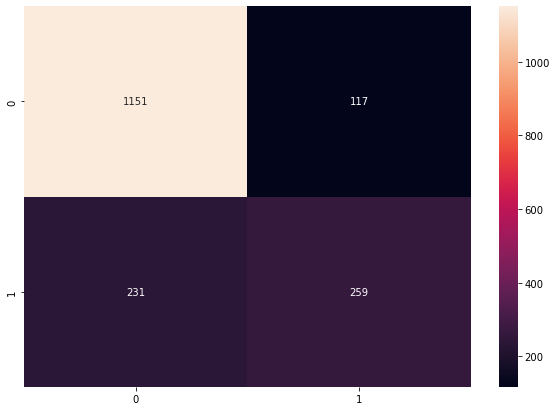

```python
# Build the confusion matrix

df_cm = pd.DataFrame(cm, index = (0, 1), columns = (0, 1))
plt.figure(figsize = (10, 7))
sns.heatmap(df_cm, annot = True, fmt ='g')
print("Test Data Accuracy: %.4f" %accuracy_score(Y_test, y_pred))
```

# Decision Tree

```python
model_tree = DecisionTreeClassifier(random_state = 2)
model_tree.fit(X_train, Y_train)
```

```
DecisionTreeClassifier(random_state=2)
```

```python
# Predicting test set

y_pred = model_tree.predict(X_test)
```

```python
# Evaluating the Results

cm = confusion_matrix(Y_test, y_pred)
print(accuracy_score(Y_test, y_pred))
print(precision_score(Y_test, y_pred))
print(recall_score(Y_test, y_pred))
print(f1_score(Y_test, y_pred))
```

```
0.732650739476678
0.521551724137931
0.49387755102040815
0.5073375262054507
```

### Q5. What do the scores mean? Is this a good model fit based on the scores.

### A5. The above mentioned scores mean the following:

- Accuracy Score: It is the ratio of number of correct predictions to total number of predictions.
- Precision Score: It measures the proportion of positive identifications was actually correct.
- Recall Score: It identifies the proportion of actual positives was identified correctly.
- F1 Score: F1 Score is the weighted average of Precision and Recall.

### Since we have imbalanced dataset, we can't rely on single value of classification.In this model, we are getting F1_score is around 0.5 which is a balance between precision and recall. Compare to Logistic Regression, Decision Tree F1_score is less.

```
Test Data Accuracy: 0.7327
```

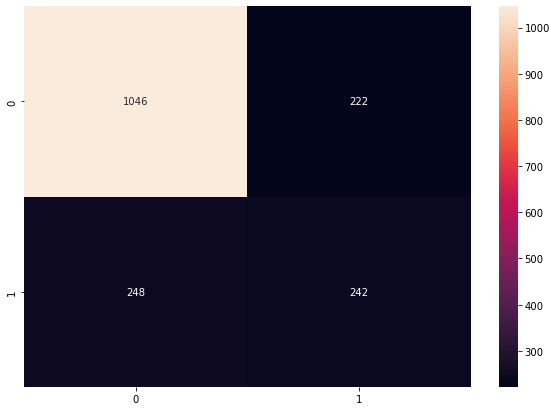

```python
# Build Confusion Matrix

df_cm = pd.DataFrame(cm, index = (0, 1), columns = (0, 1))
plt.figure(figsize = (10, 7))
sns.heatmap(df_cm, annot = True, fmt ='g')
print("Test Data Accuracy: %.4f" %accuracy_score(Y_test, y_pred))
```

### Q6. Which model performs better?

# K- fold Cross Validation

### Q7. What is K-fold cross validation?

### A7. K-Fold cross validation is a method in machine learning to evaluate machine learning models on unseen data. Here, K is the number that decides number of random groups that will be made of the given dataset. And then with each dataset we split it into testing and training data and find and compare all the values for evaluation metrics.

```python
from sklearn.model_selection import cross_val_score
accuracies = cross_val_score(estimator = classifier, X= X_train, y =Y_train, cv =10)
```

```python
# Check for accuracies

accuracies
```

```
array([0.80681818, 0.78219697, 0.82386364, 0.8219697 , 0.83301708,
       0.79316888, 0.78937381, 0.80075901, 0.80265655, 0.78937381])
```

### Q8. What do accuracies tell?

### A8. Accuracies is the way by which we can measure whether our model is performing well or not. Accuracies above tell that the machine learning model we created is working well with unseen data.

```python
# Analyzing Coefficients

pd.concat([pd.DataFrame(X_train.columns, columns =["features"]), pd.DataFrame(np.transpose(classifier.coef_),
                                                                              columns =["Coef"])],
                                                                              axis = 1)
```

|  | features | Coef |
| --- | --- | --- |
| 0 | gender | -0.089565 |
| 1 | SeniorCitizen | 0.215580 |
| 2 | Partner | 0.002618 |
| 3 | Dependents | -0.132032 |
| 4 | PhoneService | -0.178624 |
| 5 | OnlineSecurity | -0.427250 |
| 6 | OnlineBackup | -0.188926 |
| 7 | DeviceProtection | -0.008707 |
| 8 | TechSupport | -0.311266 |
| 9 | StreamingTV | 0.179637 |
| 10 | StreamingMovies | 0.257547 |
| 11 | PaperlessBilling | 0.367998 |
| 12 | MultipleLines_No | -0.276653 |
| 13 | MultipleLines_No phone service | 0.182770 |
| 14 | MultipleLines_Yes | 0.098029 |
| 15 | InternetService_DSL | -0.044044 |
| 16 | InternetService_Fiber optic | 0.652392 |
| 17 | InternetService_No | -0.604203 |
| 18 | Contract_Month-to-month | 0.721589 |
| 19 | Contract_One year | 0.028145 |
| 20 | Contract_Two year | -0.745589 |
| 21 | PaymentMethod_Bank transfer (automatic) | -0.009087 |
| 22 | PaymentMethod_Credit card (automatic) | -0.139518 |
| 23 | PaymentMethod_Electronic check | 0.225858 |
| 24 | PaymentMethod_Mailed check | -0.073107 |
| 25 | tenure_group_Tenure_0-12 | -0.251449 |
| 26 | tenure_group_Tenure_12-24 | -0.650530 |
| 27 | tenure_group_Tenure_24-48 | -0.185489 |
| 28 | tenure_group_Tenure_48-60 | 0.548552 |
| 29 | tenure_group_Tenure_gt_60 | 0.543062 |
| 30 | tenure | -1.373837 |
| 31 | MonthlyCharges | 0.188180 |
| 32 | TotalCharges | 0.248413 |

```python
df=pd.concat([pd.DataFrame(X_train.columns, columns =["features"]), pd.DataFrame(np.transpose(classifier.coef_),
                                                                              columns =["Coef"])],
                                                                              axis = 1)
```

```python
df = df.sort_values('Coef', ascending=False)
df.head()
```

|  | features | Coef |
| --- | --- | --- |
| 18 | Contract_Month-to-month | 0.721589 |
| 16 | InternetService_Fiber optic | 0.652392 |
| 28 | tenure_group_Tenure_48-60 | 0.548552 |
| 29 | tenure_group_Tenure_gt_60 | 0.543062 |
| 11 | PaperlessBilling | 0.367998 |

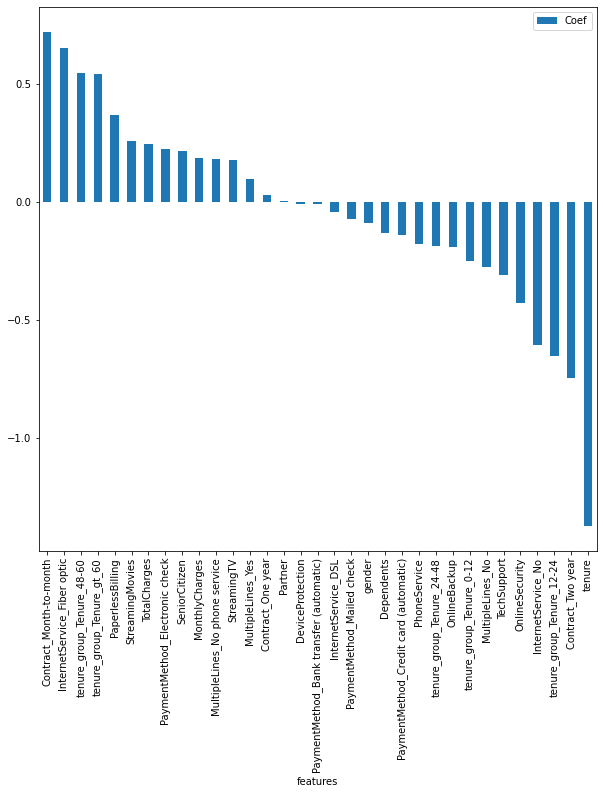

```python
ax = df.plot.bar(x='features', y='Coef', figsize=(10,10))
```

### Q9. What do you observe?

### A9. We observe that there are some features which have positive coefficients while others have negative coefficients. For visualizing it graphically, a bar plot has been made, in which 'Contract_Month-to-month' (0.72) has maximum weights. On the other hand, tenure(-1.37) has a very large negative coefficient.

# Feature Selection/Feature Engineering

```python
from sklearn.feature_selection import RFE
classifier = LogisticRegression()
rfe = RFE(classifier, 10)
rfe = rfe.fit(X_train, Y_train)
```

```python
print(rfe.support_)
```

```
[False False False False False  True False False False False  True False
  True False False False  True  True  True False  True False False False
 False False False False  True  True  True False False]
```

```python
X_train.columns[rfe.support_]
```

```
Index(['OnlineSecurity', 'StreamingMovies', 'MultipleLines_No',
       'InternetService_Fiber optic', 'InternetService_No',
       'Contract_Month-to-month', 'Contract_Two year',
       'tenure_group_Tenure_48-60', 'tenure_group_Tenure_gt_60', 'tenure'],
      dtype='object')
```

```python
rfe.ranking_
```

```
array([18,  7, 24, 14, 15,  1, 11, 23,  5,  6,  1,  3,  1, 12, 16, 20,  1,
        1,  1, 21,  1, 22, 17,  4, 19,  8,  2,  9,  1,  1,  1, 13, 10])
```

```python
# Build the model again after Feature Selection

classifier = LogisticRegression(random_state = 2)
classifier.fit(X_train[X_train.columns[rfe.support_]], Y_train)
```

```
LogisticRegression(random_state=2)
```

```python
# Evaluating the results

cm = confusion_matrix(Y_test, y_pred)
print(accuracy_score(Y_test, y_pred))
print(precision_score(Y_test, y_pred))
print(recall_score(Y_test, y_pred))
print(f1_score(Y_test, y_pred))
```

```
0.732650739476678
0.521551724137931
0.49387755102040815
0.5073375262054507
```

```
Test Data Accuracy: 0.7327
```

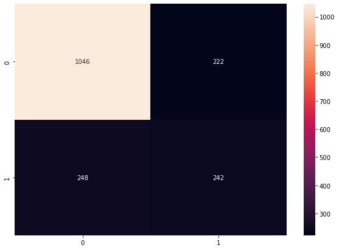

```python
df_cm = pd.DataFrame(cm, index = (0, 1), columns = (0, 1))
plt.figure(figsize = (10, 7))
sns.heatmap(df_cm, annot = True, fmt ='g')
print("Test Data Accuracy: %.4f" %accuracy_score(Y_test, y_pred))
```

```python
# Subset the coefficents for RFE

df_RFE=pd.concat([pd.DataFrame(X_train.columns[rfe.support_], columns =["features"]), pd.DataFrame(np.transpose(classifier.coef_),
                                                                              columns =["Coef"])], axis = 1)
```

### Q11. Build a bar plot similar to the one with all the features

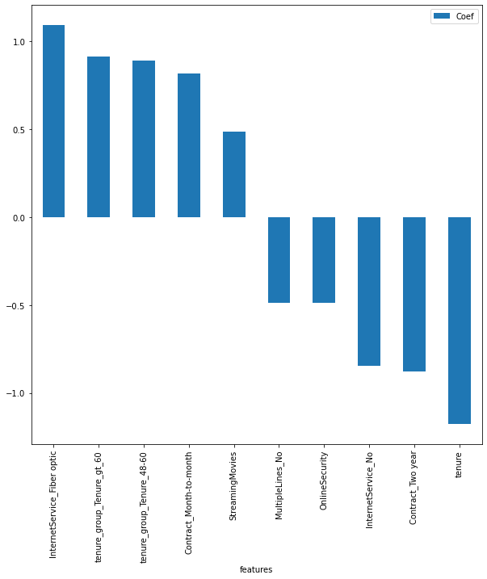

```python
df_RFE = df_RFE.sort_values('Coef', ascending=False)
ax = df_RFE.plot.bar(x='features', y='Coef', figsize=(10,10))
```

### Q12. Share your observations. Do you find them different?

### A12. We can see that the plots seem similar before and after feature selection. Top 10 features have both positive and negative values in them and at the same time they have similar values in both the directions.

```python
final_results = pd.concat([Y_test, telcom.customerID], axis =1).dropna()
final_results['predicted_churn'] = y_pred
final_results = final_results[['customerID', 'Churn', 'predicted_churn']].reset_index(drop = True)
```

### Q13. Print the final results

```python
print(final_results)
```

```
      customerID  Churn  predicted_churn
0     3668-QPYBK    1.0                0
1     7795-CFOCW    0.0                1
2     9237-HQITU    1.0                0
3     8091-TTVAX    0.0                0
4     6865-JZNKO    0.0                1
...          ...    ...              ...
1753  2823-LKABH    0.0                1
1754  6894-LFHLY    1.0                0
1755  0639-TSIQW    1.0                0
1756  4801-JZAZL    0.0                0
1757  3186-AJIEK    0.0                0

[1758 rows x 3 columns]
```

### Q14. Provide recommendations based on the feature selection. What should company target for to reduce churn?

### Based on feature selection we can following recommendations:

For feature selection, we have used RFE(Recursive Feature Elimination). This method uses accuracy metric to rank the features according to their importance. It gives 'True' for relevant feature and 'False' for irrelevant feature. We have taken out all irrelevant features based on the coefficient. After the feature scaling, there are still some features which have very large negative coefficients. For example, 'tenure' and 'Contract_Two year'. If we do not use these features in the model, Our model's accuracy can be increased.

On the other hand, there are some features which have large positive coefficients, such as 'InternetService_Fiber optic' and 'Contract_Month-to-month'. we can say, based on the coefficient value, these features are really important for the model. we should take care of these features more when we create model.

### To reduce the churn the company should:

- Focus on customers who have partners, this is because

More than 1/3rd of the customers that churned away had partners which means that these customers are not happy with the current services of Telco. The reason why they should be focused on is because Telco can reap benefits of word-of-mouth publicity of these customers two-fold as compared to customers that do not have partners. Also there is a good chance that the children of these customers will continue using their services because they have been used by their parents as well.

- Focus on customers who do not have multiple lines installed:

We can see that 54.5% of the customers that left did not have multiple lines installed. This was split between 2 sub-categories: 9.1% that did not have a phone service at all and 45.4% that did not have multiple lines. This is concerning as multiple lines would mean that the customers would be willingly paying more hence increasing the company's profits. Telco needs to revamp its marketing strategies in order to focus on this group of customers as customers are unhappy and most probably feeling that the multiple lines are not worth the cost which is why we can see such a phenomenon.

- Focus on customers who had Fiber Optic Connections:

We can see that the customers that left had the highest percentage(69.4%) of Fiber Optic Connections. Fiber Optic are higher paying connections and telco needs to change its strategies for these customers to stay. For example introducing new marketing schemes like discounts, change in subscription terms etc.

- Focus on Customers who opted out of Online Security, Online Backup, Device Protection and Tech Support

We can see that the customers do not trust Telco to keep their data and usage of services secure and they do not think its worth to invest in Online Security and Backup services. This is a niche which can prove to be quite instrumental towards attracting more customers, this is because if the security, protection and backup services are good then more customers will switch to Telco. Good tech support will prevent customers from leaving even after unhappy or unsatisfying experiences as the customers would feel valued.

- Focus on Customers who opted out of Streaming TV and Streaming Movies services:

Streaming TV and Movies are highly beneficial services which need to be targeted differently in order to extract maximum benefits as well as attract more customers. Regardless of whether the customer is loyal or leaving, most of the customers are opting out of these services.

- Focus on Encouraging Customers to go for longer contracts

Since the above services and changes need to be made, customers are opting for shorter contract options. This change can be motivated by employing the above changes.

- Focus on Getting Longer Tenures

As mentioned above, Telco needs to revamp its marketing strategies to grow. Also, the loyal customers are going with the longest tenures which means that this strategy is working for a niche of the customers which can be appropriately applied to the churn customers as well.

### Practice Q15. Can you add SVM model to this dataset and perform the same steps and check test data accuracy?

```python
import numpy as np
import matplotlib.pyplot as plt
from sklearn import svm, datasets
from sklearn.model_selection import train_test_split
```

```python
X = telcom.drop(['Churn','customerID'],axis=1)
y = telcom['Churn']
```

```python
X_train, X_test, y_train, y_test = train_test_split(X, y, test_size=0.30, random_state=123)
```

```python
# we create an instance of SVM and fit out data. We do not scale our data since we want to plot the support vectors
# C = 1.0 # SVM regularization parameter
svc = svm.SVC(kernel='linear', C=1,gamma='auto').fit(X_train, y_train) # we can use rbf, poly instead of linear too.
```

```python
svc.score(X_test,y_test)
```

```
0.79478672985782
```